# INN_Learner_Notebook_Full_code

### Neural Network with SGD Optimizer

```python
backend.clear_session()
np.random.seed(42)
import random
random.seed(42)
tf.random.set_seed(42)
```

```python
input_shape = X_train.shape[1]
input_shape
```

```
11
```

```python
model_0 = Sequential()
# First hidden layer with 128 neurons and relu activation function, the input shape tuple denotes number of independent variables
model_0.add(Dense(128, activation='relu', input_shape=(11,)))

# Second hidden layer with 64 neurons and relu activation function
model_0.add(Dense(64, activation='relu'))

# Output layer with only one neuron and sigmoid as activation function will give the probability of students getting admitted into UCLA
model_0.add(Dense(1, activation='sigmoid'))

optimizer = SGD(learning_rate=0.01)
model_0.compile(loss='binary_crossentropy', optimizer=optimizer, metrics=['recall'])
```

```python
model_0.summary()
```

```
Model: "sequential_1"
```

```
┏━━━━━━━━━━━━━━━━━━━━━━━━━━━━━━━━━━━━━━┳━━━━━━━━━━━━━━━━━━━━━━━━━━━━━┳━━━━━━━━━━━━━━━━━┓
┃ Layer (type)                         ┃ Output Shape                ┃         Param # ┃
┡━━━━━━━━━━━━━━━━━━━━━━━━━━━━━━━━━━━━━━╇━━━━━━━━━━━━━━━━━━━━━━━━━━━━━╇━━━━━━━━━━━━━━━━━┩
│ dense_3 (Dense)                      │ (None, 128)                 │           1,536 │
├──────────────────────────────────────┼─────────────────────────────┼─────────────────┤
│ dense_4 (Dense)                      │ (None, 64)                  │           8,256 │
├──────────────────────────────────────┼─────────────────────────────┼─────────────────┤
│ dense_5 (Dense)                      │ (None, 1)                   │              65 │
└──────────────────────────────────────┴─────────────────────────────┴─────────────────┘
```

```
 Total params: 9,857 (38.50 KB)
```

```
 Trainable params: 9,857 (38.50 KB)
```

```
 Non-trainable params: 0 (0.00 B)
```

```python
history_0 = model_0.fit(X_train,
                    y_train,
                    validation_data=(X_valid, y_valid),
                    batch_size=32,
                    epochs=150,
                    verbose=1)
```

```
200/200 ━━━━━━━━━━━━━━━━━━━━ 2s 5ms/step - loss: 0.6628 - recall: 0.3151 - val_loss: 0.4781 - val_recall: 0.0000e+00
200/200 ━━━━━━━━━━━━━━━━━━━━ 1s 3ms/step - loss: 0.4788 - recall: 0.0000e+00 - val_loss: 0.4564 - val_recall: 0.0030
200/200 ━━━━━━━━━━━━━━━━━━━━ 1s 3ms/step - loss: 0.4576 - recall: 0.0067 - val_loss: 0.4423 - val_recall: 0.0213
200/200 ━━━━━━━━━━━━━━━━━━━━ 1s 2ms/step - loss: 0.4418 - recall: 0.0286 - val_loss: 0.4322 - val_recall: 0.0790
200/200 ━━━━━━━━━━━━━━━━━━━━ 1s 2ms/step - loss: 0.4296 - recall: 0.0835 - val_loss: 0.4249 - val_recall: 0.1216
200/200 ━━━━━━━━━━━━━━━━━━━━ 1s 2ms/step - loss: 0.4199 - recall: 0.1628 - val_loss: 0.4189 - val_recall: 0.1641
200/200 ━━━━━━━━━━━━━━━━━━━━ 1s 2ms/step - loss: 0.4117 - recall: 0.2188 - val_loss: 0.4137 - val_recall: 0.2097
200/200 ━━━━━━━━━━━━━━━━━━━━ 0s 2ms/step - loss: 0.4044 - recall: 0.2530 - val_loss: 0.4087 - val_recall: 0.2644
200/200 ━━━━━━━━━━━━━━━━━━━━ 1s 2ms/step - loss: 0.3976 - recall: 0.2880 - val_loss: 0.4038 - val_recall: 0.2766
200/200 ━━━━━━━━━━━━━━━━━━━━ 0s 2ms/step - loss: 0.3910 - recall: 0.3235 - val_loss: 0.3988 - val_recall: 0.2979
200/200 ━━━━━━━━━━━━━━━━━━━━ 1s 2ms/step - loss: 0.3846 - recall: 0.3598 - val_loss: 0.3938 - val_recall: 0.3131
200/200 ━━━━━━━━━━━━━━━━━━━━ 1s 2ms/step - loss: 0.3784 - recall: 0.3822 - val_loss: 0.3890 - val_recall: 0.3252
200/200 ━━━━━━━━━━━━━━━━━━━━ 0s 2ms/step - loss: 0.3726 - recall: 0.3924 - val_loss: 0.3843 - val_recall: 0.3283
200/200 ━━━━━━━━━━━━━━━━━━━━ 1s 2ms/step - loss: 0.3673 - recall: 0.4074 - val_loss: 0.3799 - val_recall: 0.3495
200/200 ━━━━━━━━━━━━━━━━━━━━ 1s 2ms/step - loss: 0.3623 - recall: 0.4231 - val_loss: 0.3758 - val_recall: 0.3587
200/200 ━━━━━━━━━━━━━━━━━━━━ 0s 2ms/step - loss: 0.3577 - recall: 0.4320 - val_loss: 0.3721 - val_recall: 0.3587
200/200 ━━━━━━━━━━━━━━━━━━━━ 1s 2ms/step - loss: 0.3537 - recall: 0.4421 - val_loss: 0.3687 - val_recall: 0.3678
200/200 ━━━━━━━━━━━━━━━━━━━━ 1s 2ms/step - loss: 0.3500 - recall: 0.4542 - val_loss: 0.3657 - val_recall: 0.3769
200/200 ━━━━━━━━━━━━━━━━━━━━ 0s 2ms/step - loss: 0.3469 - recall: 0.4570 - val_loss: 0.3632 - val_recall: 0.3860
200/200 ━━━━━━━━━━━━━━━━━━━━ 1s 2ms/step - loss: 0.3442 - recall: 0.4622 - val_loss: 0.3609 - val_recall: 0.3921
200/200 ━━━━━━━━━━━━━━━━━━━━ 1s 2ms/step - loss: 0.3418 - recall: 0.4649 - val_loss: 0.3589 - val_recall: 0.3921
200/200 ━━━━━━━━━━━━━━━━━━━━ 1s 3ms/step - loss: 0.3397 - recall: 0.4727 - val_loss: 0.3572 - val_recall: 0.4012
200/200 ━━━━━━━━━━━━━━━━━━━━ 1s 3ms/step - loss: 0.3379 - recall: 0.4785 - val_loss: 0.3557 - val_recall: 0.4073
200/200 ━━━━━━━━━━━━━━━━━━━━ 1s 3ms/step - loss: 0.3363 - recall: 0.4839 - val_loss: 0.3544 - val_recall: 0.4134
200/200 ━━━━━━━━━━━━━━━━━━━━ 1s 3ms/step - loss: 0.3349 - recall: 0.4873 - val_loss: 0.3532 - val_recall: 0.4195
200/200 ━━━━━━━━━━━━━━━━━━━━ 1s 2ms/step - loss: 0.3337 - recall: 0.4879 - val_loss: 0.3522 - val_recall: 0.4195
200/200 ━━━━━━━━━━━━━━━━━━━━ 0s 2ms/step - loss: 0.3325 - recall: 0.4876 - val_loss: 0.3513 - val_recall: 0.4255
200/200 ━━━━━━━━━━━━━━━━━━━━ 1s 2ms/step - loss: 0.3314 - recall: 0.4898 - val_loss: 0.3505 - val_recall: 0.4286
200/200 ━━━━━━━━━━━━━━━━━━━━ 1s 2ms/step - loss: 0.3305 - recall: 0.4915 - val_loss: 0.3498 - val_recall: 0.4347
200/200 ━━━━━━━━━━━━━━━━━━━━ 1s 2ms/step - loss: 0.3296 - recall: 0.4916 - val_loss: 0.3492 - val_recall: 0.4377
200/200 ━━━━━━━━━━━━━━━━━━━━ 1s 2ms/step - loss: 0.3287 - recall: 0.4927 - val_loss: 0.3486 - val_recall: 0.4377
200/200 ━━━━━━━━━━━━━━━━━━━━ 0s 2ms/step - loss: 0.3279 - recall: 0.4962 - val_loss: 0.3481 - val_recall: 0.4377
200/200 ━━━━━━━━━━━━━━━━━━━━ 0s 2ms/step - loss: 0.3271 - recall: 0.4963 - val_loss: 0.3476 - val_recall: 0.4377
200/200 ━━━━━━━━━━━━━━━━━━━━ 1s 2ms/step - loss: 0.3264 - recall: 0.4966 - val_loss: 0.3472 - val_recall: 0.4377
200/200 ━━━━━━━━━━━━━━━━━━━━ 1s 2ms/step - loss: 0.3257 - recall: 0.4974 - val_loss: 0.3468 - val_recall: 0.4377
200/200 ━━━━━━━━━━━━━━━━━━━━ 1s 2ms/step - loss: 0.3250 - recall: 0.5002 - val_loss: 0.3464 - val_recall: 0.4377
200/200 ━━━━━━━━━━━━━━━━━━━━ 0s 2ms/step - loss: 0.3244 - recall: 0.5017 - val_loss: 0.3461 - val_recall: 0.4377
200/200 ━━━━━━━━━━━━━━━━━━━━ 1s 2ms/step - loss: 0.3238 - recall: 0.5002 - val_loss: 0.3458 - val_recall: 0.4377
200/200 ━━━━━━━━━━━━━━━━━━━━ 1s 2ms/step - loss: 0.3232 - recall: 0.5017 - val_loss: 0.3455 - val_recall: 0.4377
200/200 ━━━━━━━━━━━━━━━━━━━━ 1s 2ms/step - loss: 0.3226 - recall: 0.5022 - val_loss: 0.3452 - val_recall: 0.4347
```

[output cut: 95 more lines]

```
200/200 ━━━━━━━━━━━━━━━━━━━━ 1s 3ms/step - loss: 0.2866 - recall: 0.5478 - val_loss: 0.3426 - val_recall: 0.4894
200/200 ━━━━━━━━━━━━━━━━━━━━ 1s 3ms/step - loss: 0.2863 - recall: 0.5483 - val_loss: 0.3428 - val_recall: 0.4894
200/200 ━━━━━━━━━━━━━━━━━━━━ 0s 2ms/step - loss: 0.2860 - recall: 0.5478 - val_loss: 0.3429 - val_recall: 0.4894
200/200 ━━━━━━━━━━━━━━━━━━━━ 1s 2ms/step - loss: 0.2856 - recall: 0.5478 - val_loss: 0.3430 - val_recall: 0.4894
200/200 ━━━━━━━━━━━━━━━━━━━━ 1s 2ms/step - loss: 0.2853 - recall: 0.5498 - val_loss: 0.3431 - val_recall: 0.4894
200/200 ━━━━━━━━━━━━━━━━━━━━ 1s 2ms/step - loss: 0.2850 - recall: 0.5503 - val_loss: 0.3433 - val_recall: 0.4894
200/200 ━━━━━━━━━━━━━━━━━━━━ 1s 2ms/step - loss: 0.2846 - recall: 0.5503 - val_loss: 0.3434 - val_recall: 0.4894
200/200 ━━━━━━━━━━━━━━━━━━━━ 0s 2ms/step - loss: 0.2843 - recall: 0.5506 - val_loss: 0.3435 - val_recall: 0.4894
200/200 ━━━━━━━━━━━━━━━━━━━━ 1s 2ms/step - loss: 0.2840 - recall: 0.5511 - val_loss: 0.3436 - val_recall: 0.4894
200/200 ━━━━━━━━━━━━━━━━━━━━ 1s 2ms/step - loss: 0.2836 - recall: 0.5506 - val_loss: 0.3438 - val_recall: 0.4894
200/200 ━━━━━━━━━━━━━━━━━━━━ 0s 2ms/step - loss: 0.2833 - recall: 0.5506 - val_loss: 0.3439 - val_recall: 0.4894
200/200 ━━━━━━━━━━━━━━━━━━━━ 1s 2ms/step - loss: 0.2830 - recall: 0.5507 - val_loss: 0.3441 - val_recall: 0.4894
200/200 ━━━━━━━━━━━━━━━━━━━━ 1s 2ms/step - loss: 0.2826 - recall: 0.5513 - val_loss: 0.3442 - val_recall: 0.4894
200/200 ━━━━━━━━━━━━━━━━━━━━ 1s 2ms/step - loss: 0.2823 - recall: 0.5518 - val_loss: 0.3443 - val_recall: 0.4894
200/200 ━━━━━━━━━━━━━━━━━━━━ 1s 2ms/step - loss: 0.2820 - recall: 0.5561 - val_loss: 0.3444 - val_recall: 0.4894
```

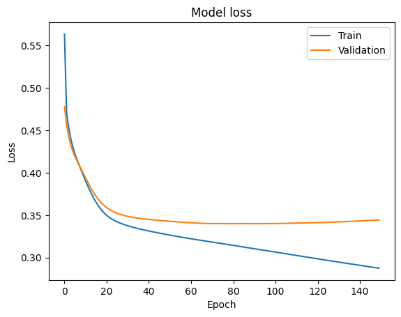

```python
#plot loss
plt.plot(history_0.history['loss'])
plt.plot(history_0.history['val_loss'])
plt.title('Model loss')
plt.ylabel('Loss')
plt.xlabel('Epoch')
plt.legend(['Train', 'Validation'], loc='upper right')
```

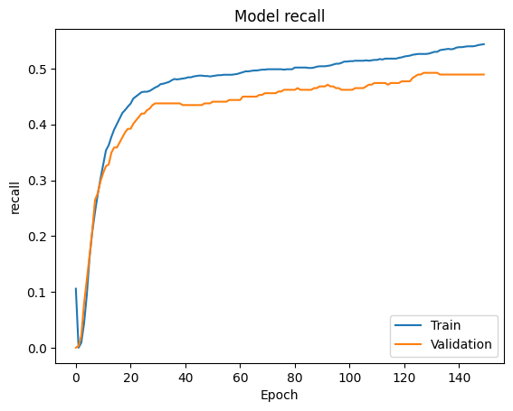

```python
#plot recall
plt.plot(history_0.history['recall'])
plt.plot(history_0.history['val_recall'])
plt.title('Model recall')
plt.ylabel('recall')
plt.xlabel('Epoch')
plt.legend(['Train', 'Validation'], loc='lower right')
```

```python
y_train_pred = model_0.predict(X_train)
y_train_pred = (y_train_pred > 0.5)
y_valid_pred = model_0.predict(X_valid)
y_valid_pred = (y_valid_pred > 0.5)
y_test_pred = model_0.predict(X_test)
y_test_pred = (y_test_pred > 0.5)
y_train_pred, y_valid_pred, y_test_pred #get predictions
```

```
200/200 ━━━━━━━━━━━━━━━━━━━━ 0s 1ms/step
50/50 ━━━━━━━━━━━━━━━━━━━━ 0s 1ms/step
63/63 ━━━━━━━━━━━━━━━━━━━━ 0s 2ms/step
```

```
(array([[ True],
        [False],
        [False],
        ...,
        [False],
        [ True],
        [False]]),
 array([[False],
        [False],
        [False],
        ...,
        [False],
        [False],
        [False]]),
 array([[False],
        [False],
        [False],
        ...,
        [ True],
        [False],
        [False]]))
```

```python
cr=classification_report(y_train, y_train_pred)
print(cr) #get stats from train data
```

```
              precision    recall  f1-score   support

           0       0.89      0.97      0.93      5085
           1       0.83      0.55      0.66      1315

    accuracy                           0.88      6400
   macro avg       0.86      0.76      0.79      6400
weighted avg       0.88      0.88      0.87      6400
```

```python
cr=classification_report(y_valid, y_valid_pred)
print(cr) #get stats from validation data
```

```
              precision    recall  f1-score   support

           0       0.88      0.95      0.91      1271
           1       0.70      0.49      0.58       329

    accuracy                           0.85      1600
   macro avg       0.79      0.72      0.74      1600
weighted avg       0.84      0.85      0.84      1600
```

```python
recall_results = {}
recall_results['model_0'] = [f"Train: {recall_score(y_train, y_train_pred)}", f"Validation: {recall_score(y_valid, y_valid_pred)}"]
recall_results
```

```
{'model_0': ['Train: 0.5452471482889734', 'Validation: 0.48936170212765956']}
```

## Model Performance Improvement

### Neural Network with Adam Optimizer

```python
backend.clear_session()
np.random.seed(42)
random.seed(42)
tf.random.set_seed(42)
```

```python
model_1 = Sequential()
# First hidden layer with 128 neurons and relu activation function, the input shape tuple denotes number of independent variables
model_1.add(Dense(128, activation='relu', input_shape=(11,)))

# Second hidden layer with 64 neurons and relu activation function
model_1.add(Dense(64, activation='relu'))

# Output layer with only one neuron and sigmoid as activation function will give the probability of students getting admitted into UCLA
model_1.add(Dense(1, activation='sigmoid'))

optimizer = Adam(learning_rate=0.01)
model_1.compile(loss='binary_crossentropy', optimizer=optimizer, metrics=['recall'])
```

```python
model_1.summary()
```

```
Model: "sequential"
```

```
┏━━━━━━━━━━━━━━━━━━━━━━━━━━━━━━━━━━━━━━┳━━━━━━━━━━━━━━━━━━━━━━━━━━━━━┳━━━━━━━━━━━━━━━━━┓
┃ Layer (type)                         ┃ Output Shape                ┃         Param # ┃
┡━━━━━━━━━━━━━━━━━━━━━━━━━━━━━━━━━━━━━━╇━━━━━━━━━━━━━━━━━━━━━━━━━━━━━╇━━━━━━━━━━━━━━━━━┩
│ dense (Dense)                        │ (None, 128)                 │           1,536 │
├──────────────────────────────────────┼─────────────────────────────┼─────────────────┤
│ dense_1 (Dense)                      │ (None, 64)                  │           8,256 │
├──────────────────────────────────────┼─────────────────────────────┼─────────────────┤
│ dense_2 (Dense)                      │ (None, 1)                   │              65 │
└──────────────────────────────────────┴─────────────────────────────┴─────────────────┘
```

```
 Total params: 9,857 (38.50 KB)
```

```
 Trainable params: 9,857 (38.50 KB)
```

```
 Non-trainable params: 0 (0.00 B)
```

```python
history_1 = model_1.fit(X_train,
                    y_train,
                    validation_data=(X_valid, y_valid),
                    batch_size=32,
                    epochs=150,
                    verbose=1)
```

```
200/200 ━━━━━━━━━━━━━━━━━━━━ 3s 5ms/step - loss: 0.4421 - recall: 0.3208 - val_loss: 0.3549 - val_recall: 0.3982
200/200 ━━━━━━━━━━━━━━━━━━━━ 1s 4ms/step - loss: 0.3518 - recall: 0.4587 - val_loss: 0.3516 - val_recall: 0.4529
200/200 ━━━━━━━━━━━━━━━━━━━━ 1s 3ms/step - loss: 0.3434 - recall: 0.4725 - val_loss: 0.3493 - val_recall: 0.4772
200/200 ━━━━━━━━━━━━━━━━━━━━ 1s 3ms/step - loss: 0.3387 - recall: 0.4765 - val_loss: 0.3474 - val_recall: 0.4620
200/200 ━━━━━━━━━━━━━━━━━━━━ 1s 3ms/step - loss: 0.3330 - recall: 0.4787 - val_loss: 0.3481 - val_recall: 0.4772
200/200 ━━━━━━━━━━━━━━━━━━━━ 1s 3ms/step - loss: 0.3304 - recall: 0.4806 - val_loss: 0.3509 - val_recall: 0.4863
200/200 ━━━━━━━━━━━━━━━━━━━━ 1s 2ms/step - loss: 0.3270 - recall: 0.4947 - val_loss: 0.3504 - val_recall: 0.4468
200/200 ━━━━━━━━━━━━━━━━━━━━ 1s 2ms/step - loss: 0.3250 - recall: 0.5027 - val_loss: 0.3537 - val_recall: 0.4590
200/200 ━━━━━━━━━━━━━━━━━━━━ 0s 2ms/step - loss: 0.3218 - recall: 0.5054 - val_loss: 0.3543 - val_recall: 0.4681
200/200 ━━━━━━━━━━━━━━━━━━━━ 0s 2ms/step - loss: 0.3205 - recall: 0.4992 - val_loss: 0.3591 - val_recall: 0.4498
200/200 ━━━━━━━━━━━━━━━━━━━━ 1s 2ms/step - loss: 0.3163 - recall: 0.5110 - val_loss: 0.3643 - val_recall: 0.4255
200/200 ━━━━━━━━━━━━━━━━━━━━ 0s 2ms/step - loss: 0.3141 - recall: 0.5131 - val_loss: 0.3686 - val_recall: 0.4620
200/200 ━━━━━━━━━━━━━━━━━━━━ 0s 2ms/step - loss: 0.3120 - recall: 0.5266 - val_loss: 0.3677 - val_recall: 0.4468
200/200 ━━━━━━━━━━━━━━━━━━━━ 1s 2ms/step - loss: 0.3069 - recall: 0.5354 - val_loss: 0.3668 - val_recall: 0.4377
200/200 ━━━━━━━━━━━━━━━━━━━━ 1s 2ms/step - loss: 0.3013 - recall: 0.5527 - val_loss: 0.3728 - val_recall: 0.4681
200/200 ━━━━━━━━━━━━━━━━━━━━ 1s 3ms/step - loss: 0.2944 - recall: 0.5482 - val_loss: 0.3823 - val_recall: 0.4650
200/200 ━━━━━━━━━━━━━━━━━━━━ 1s 3ms/step - loss: 0.2967 - recall: 0.5506 - val_loss: 0.3986 - val_recall: 0.4590
200/200 ━━━━━━━━━━━━━━━━━━━━ 1s 4ms/step - loss: 0.2928 - recall: 0.5564 - val_loss: 0.3886 - val_recall: 0.4681
200/200 ━━━━━━━━━━━━━━━━━━━━ 1s 2ms/step - loss: 0.2858 - recall: 0.5592 - val_loss: 0.3991 - val_recall: 0.4286
200/200 ━━━━━━━━━━━━━━━━━━━━ 1s 2ms/step - loss: 0.2849 - recall: 0.5698 - val_loss: 0.4065 - val_recall: 0.4498
200/200 ━━━━━━━━━━━━━━━━━━━━ 1s 2ms/step - loss: 0.2819 - recall: 0.5745 - val_loss: 0.4130 - val_recall: 0.4316
200/200 ━━━━━━━━━━━━━━━━━━━━ 1s 2ms/step - loss: 0.2735 - recall: 0.5910 - val_loss: 0.4415 - val_recall: 0.4347
200/200 ━━━━━━━━━━━━━━━━━━━━ 1s 2ms/step - loss: 0.2703 - recall: 0.5939 - val_loss: 0.4258 - val_recall: 0.4286
200/200 ━━━━━━━━━━━━━━━━━━━━ 1s 2ms/step - loss: 0.2697 - recall: 0.5858 - val_loss: 0.4162 - val_recall: 0.4286
200/200 ━━━━━━━━━━━━━━━━━━━━ 1s 2ms/step - loss: 0.2649 - recall: 0.5844 - val_loss: 0.4476 - val_recall: 0.4498
200/200 ━━━━━━━━━━━━━━━━━━━━ 1s 2ms/step - loss: 0.2628 - recall: 0.5966 - val_loss: 0.4632 - val_recall: 0.4438
200/200 ━━━━━━━━━━━━━━━━━━━━ 1s 2ms/step - loss: 0.2557 - recall: 0.5926 - val_loss: 0.4648 - val_recall: 0.4316
200/200 ━━━━━━━━━━━━━━━━━━━━ 0s 2ms/step - loss: 0.2552 - recall: 0.5800 - val_loss: 0.4520 - val_recall: 0.3982
200/200 ━━━━━━━━━━━━━━━━━━━━ 0s 2ms/step - loss: 0.2544 - recall: 0.5892 - val_loss: 0.4633 - val_recall: 0.4498
200/200 ━━━━━━━━━━━━━━━━━━━━ 1s 2ms/step - loss: 0.2518 - recall: 0.5893 - val_loss: 0.4663 - val_recall: 0.4286
200/200 ━━━━━━━━━━━━━━━━━━━━ 1s 2ms/step - loss: 0.2502 - recall: 0.5823 - val_loss: 0.4855 - val_recall: 0.4407
200/200 ━━━━━━━━━━━━━━━━━━━━ 1s 2ms/step - loss: 0.2494 - recall: 0.5971 - val_loss: 0.4523 - val_recall: 0.4438
200/200 ━━━━━━━━━━━━━━━━━━━━ 1s 2ms/step - loss: 0.2442 - recall: 0.6073 - val_loss: 0.4755 - val_recall: 0.4286
200/200 ━━━━━━━━━━━━━━━━━━━━ 1s 2ms/step - loss: 0.2334 - recall: 0.6133 - val_loss: 0.5115 - val_recall: 0.4377
200/200 ━━━━━━━━━━━━━━━━━━━━ 1s 3ms/step - loss: 0.2353 - recall: 0.6032 - val_loss: 0.5174 - val_recall: 0.4377
200/200 ━━━━━━━━━━━━━━━━━━━━ 1s 3ms/step - loss: 0.2280 - recall: 0.6269 - val_loss: 0.5141 - val_recall: 0.4468
200/200 ━━━━━━━━━━━━━━━━━━━━ 1s 3ms/step - loss: 0.2331 - recall: 0.6126 - val_loss: 0.5133 - val_recall: 0.4286
200/200 ━━━━━━━━━━━━━━━━━━━━ 1s 3ms/step - loss: 0.2273 - recall: 0.6275 - val_loss: 0.5756 - val_recall: 0.4286
200/200 ━━━━━━━━━━━━━━━━━━━━ 1s 4ms/step - loss: 0.2287 - recall: 0.6281 - val_loss: 0.5469 - val_recall: 0.4407
200/200 ━━━━━━━━━━━━━━━━━━━━ 1s 2ms/step - loss: 0.2295 - recall: 0.6096 - val_loss: 0.5429 - val_recall: 0.4347
```

[output cut: 95 more lines]

```
200/200 ━━━━━━━━━━━━━━━━━━━━ 1s 4ms/step - loss: 0.1132 - recall: 0.9146 - val_loss: 1.1942 - val_recall: 0.5927
200/200 ━━━━━━━━━━━━━━━━━━━━ 1s 4ms/step - loss: 0.1101 - recall: 0.9248 - val_loss: 1.3145 - val_recall: 0.5927
200/200 ━━━━━━━━━━━━━━━━━━━━ 1s 4ms/step - loss: 0.1074 - recall: 0.9151 - val_loss: 1.3703 - val_recall: 0.5623
200/200 ━━━━━━━━━━━━━━━━━━━━ 1s 3ms/step - loss: 0.1105 - recall: 0.9142 - val_loss: 1.3169 - val_recall: 0.5653
200/200 ━━━━━━━━━━━━━━━━━━━━ 0s 2ms/step - loss: 0.1208 - recall: 0.8940 - val_loss: 1.3531 - val_recall: 0.4498
200/200 ━━━━━━━━━━━━━━━━━━━━ 0s 2ms/step - loss: 0.1388 - recall: 0.7487 - val_loss: 1.2500 - val_recall: 0.4498
200/200 ━━━━━━━━━━━━━━━━━━━━ 1s 2ms/step - loss: 0.1132 - recall: 0.7656 - val_loss: 1.2678 - val_recall: 0.4498
200/200 ━━━━━━━━━━━━━━━━━━━━ 1s 2ms/step - loss: 0.1094 - recall: 0.8008 - val_loss: 1.3302 - val_recall: 0.5836
200/200 ━━━━━━━━━━━━━━━━━━━━ 1s 2ms/step - loss: 0.1023 - recall: 0.9185 - val_loss: 1.4447 - val_recall: 0.5988
200/200 ━━━━━━━━━━━━━━━━━━━━ 1s 2ms/step - loss: 0.0948 - recall: 0.9277 - val_loss: 1.5676 - val_recall: 0.5714
200/200 ━━━━━━━━━━━━━━━━━━━━ 1s 2ms/step - loss: 0.1250 - recall: 0.9169 - val_loss: 1.3965 - val_recall: 0.4195
200/200 ━━━━━━━━━━━━━━━━━━━━ 1s 2ms/step - loss: 0.1455 - recall: 0.8616 - val_loss: 1.4114 - val_recall: 0.5866
200/200 ━━━━━━━━━━━━━━━━━━━━ 1s 2ms/step - loss: 0.1139 - recall: 0.9115 - val_loss: 1.3779 - val_recall: 0.5775
200/200 ━━━━━━━━━━━━━━━━━━━━ 1s 2ms/step - loss: 0.1276 - recall: 0.9035 - val_loss: 1.3266 - val_recall: 0.5653
200/200 ━━━━━━━━━━━━━━━━━━━━ 1s 2ms/step - loss: 0.1072 - recall: 0.9148 - val_loss: 1.3594 - val_recall: 0.5714
```

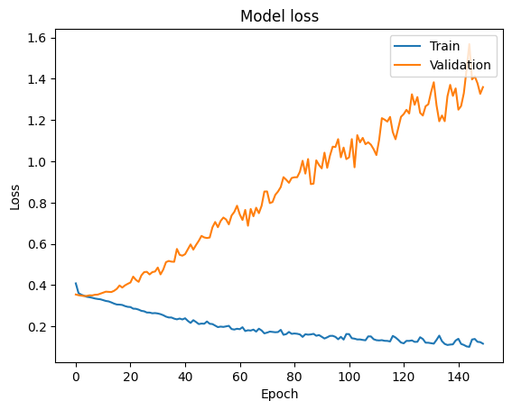

```python
#plot loss function
plt.plot(history_1.history['loss'])
plt.plot(history_1.history['val_loss'])
plt.title('Model loss')
plt.ylabel('Loss')
plt.xlabel('Epoch')
plt.legend(['Train', 'Validation'], loc='upper right')
```

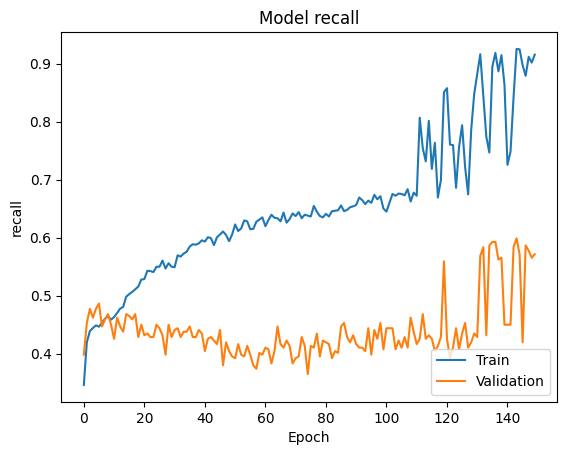

```python
#plot recall
plt.plot(history_1.history['recall'])
plt.plot(history_1.history['val_recall'])
plt.title('Model recall')
plt.ylabel('recall')
plt.xlabel('Epoch')
plt.legend(['Train', 'Validation'], loc='lower right')
```

```python
y_train_pred = model_1.predict(X_train)
y_train_pred = (y_train_pred > 0.5)
y_valid_pred = model_1.predict(X_valid)
y_valid_pred = (y_valid_pred > 0.5)
y_test_pred = model_1.predict(X_test)
y_test_pred = (y_test_pred > 0.5)
y_train_pred, y_valid_pred, y_test_pred #get predictions from model
```

```
200/200 ━━━━━━━━━━━━━━━━━━━━ 0s 1ms/step
50/50 ━━━━━━━━━━━━━━━━━━━━ 0s 1ms/step
63/63 ━━━━━━━━━━━━━━━━━━━━ 0s 2ms/step
```

```
(array([[ True],
        [False],
        [False],
        ...,
        [False],
        [ True],
        [False]]),
 array([[False],
        [False],
        [ True],
        ...,
        [False],
        [False],
        [False]]),
 array([[False],
        [False],
        [False],
        ...,
        [ True],
        [False],
        [ True]]))
```

```python
cr=classification_report(y_train, y_train_pred)
print(cr) #get stats from validation data
```

```
              precision    recall  f1-score   support

           0       0.98      0.95      0.96      5085
           1       0.82      0.91      0.87      1315

    accuracy                           0.94      6400
   macro avg       0.90      0.93      0.91      6400
weighted avg       0.95      0.94      0.94      6400
```

```python
cr=classification_report(y_valid, y_valid_pred)
print(cr) #get stats from validation data
```

```
              precision    recall  f1-score   support

           0       0.89      0.88      0.88      1271
           1       0.55      0.57      0.56       329

    accuracy                           0.81      1600
   macro avg       0.72      0.72      0.72      1600
weighted avg       0.82      0.81      0.82      1600
```

```python
recall_results['model_1'] = [f"Train: {recall_score(y_train, y_train_pred)}", f"Validation: {recall_score(y_valid, y_valid_pred)}"]
recall_results
```

```
{'model_0': ['Train: 0.5452471482889734', 'Validation: 0.48936170212765956'],
 'model_1': ['Train: 0.9140684410646388', 'Validation: 0.5714285714285714']}
```

### Neural Network with Adam Optimizer and Dropout

```python
backend.clear_session()
np.random.seed(42)
random.seed(42)
tf.random.set_seed(42)
```

```python
model_2 = Sequential()
# First hidden layer with 128 neurons and relu activation function, the input shape tuple denotes number of independent variables
model_2.add(Dense(128, activation='relu', input_shape=(11,)))

#switching 20% of neurons off randomly at each iteration to avoid overfitting
model_2.add(Dropout(0.2))

# Second hidden layer with 64 neurons and relu activation function
model_2.add(Dense(64, activation='relu'))

#switching 10% of neurons off randomly at each iteration to avoid overfitting
model_2.add(Dropout(0.1))

# Output layer with only one neuron and sigmoid as activation function will give the probability of students getting admitted into UCLA
model_2.add(Dense(1, activation='sigmoid'))

optimizer = Adam(learning_rate=0.01)
model_2.compile(loss='binary_crossentropy', optimizer=optimizer, metrics=['recall'])
```

```python
model_2.summary()
```

```
Model: "sequential"
```

```
┏━━━━━━━━━━━━━━━━━━━━━━━━━━━━━━━━━━━━━━┳━━━━━━━━━━━━━━━━━━━━━━━━━━━━━┳━━━━━━━━━━━━━━━━━┓
┃ Layer (type)                         ┃ Output Shape                ┃         Param # ┃
┡━━━━━━━━━━━━━━━━━━━━━━━━━━━━━━━━━━━━━━╇━━━━━━━━━━━━━━━━━━━━━━━━━━━━━╇━━━━━━━━━━━━━━━━━┩
│ dense (Dense)                        │ (None, 128)                 │           1,536 │
├──────────────────────────────────────┼─────────────────────────────┼─────────────────┤
│ dropout (Dropout)                    │ (None, 128)                 │               0 │
├──────────────────────────────────────┼─────────────────────────────┼─────────────────┤
│ dense_1 (Dense)                      │ (None, 64)                  │           8,256 │
├──────────────────────────────────────┼─────────────────────────────┼─────────────────┤
│ dropout_1 (Dropout)                  │ (None, 64)                  │               0 │
├──────────────────────────────────────┼─────────────────────────────┼─────────────────┤
│ dense_2 (Dense)                      │ (None, 1)                   │              65 │
└──────────────────────────────────────┴─────────────────────────────┴─────────────────┘
```

```
 Total params: 9,857 (38.50 KB)
```

```
 Trainable params: 9,857 (38.50 KB)
```

```
 Non-trainable params: 0 (0.00 B)
```

```python
history_2 = model_2.fit(X_train,
                    y_train,
                    validation_data=(X_valid, y_valid),
                    batch_size=32,
                    epochs=150,
                    verbose=1)
```

```
200/200 ━━━━━━━━━━━━━━━━━━━━ 3s 5ms/step - loss: 0.4406 - recall: 0.3022 - val_loss: 0.3545 - val_recall: 0.3374
200/200 ━━━━━━━━━━━━━━━━━━━━ 1s 4ms/step - loss: 0.3651 - recall: 0.4408 - val_loss: 0.3455 - val_recall: 0.4407
200/200 ━━━━━━━━━━━━━━━━━━━━ 1s 4ms/step - loss: 0.3536 - recall: 0.4498 - val_loss: 0.3576 - val_recall: 0.4772
200/200 ━━━━━━━━━━━━━━━━━━━━ 1s 2ms/step - loss: 0.3502 - recall: 0.4530 - val_loss: 0.3536 - val_recall: 0.4316
200/200 ━━━━━━━━━━━━━━━━━━━━ 1s 2ms/step - loss: 0.3485 - recall: 0.4700 - val_loss: 0.3478 - val_recall: 0.4468
200/200 ━━━━━━━━━━━━━━━━━━━━ 1s 2ms/step - loss: 0.3517 - recall: 0.4274 - val_loss: 0.3507 - val_recall: 0.4407
200/200 ━━━━━━━━━━━━━━━━━━━━ 1s 2ms/step - loss: 0.3404 - recall: 0.4799 - val_loss: 0.3459 - val_recall: 0.4438
200/200 ━━━━━━━━━━━━━━━━━━━━ 0s 2ms/step - loss: 0.3462 - recall: 0.4641 - val_loss: 0.3580 - val_recall: 0.4012
200/200 ━━━━━━━━━━━━━━━━━━━━ 1s 3ms/step - loss: 0.3455 - recall: 0.4786 - val_loss: 0.3458 - val_recall: 0.4255
200/200 ━━━━━━━━━━━━━━━━━━━━ 1s 2ms/step - loss: 0.3409 - recall: 0.4696 - val_loss: 0.3612 - val_recall: 0.4711
200/200 ━━━━━━━━━━━━━━━━━━━━ 0s 2ms/step - loss: 0.3440 - recall: 0.4787 - val_loss: 0.3510 - val_recall: 0.4559
200/200 ━━━━━━━━━━━━━━━━━━━━ 1s 2ms/step - loss: 0.3373 - recall: 0.4731 - val_loss: 0.3469 - val_recall: 0.4529
200/200 ━━━━━━━━━━━━━━━━━━━━ 1s 2ms/step - loss: 0.3353 - recall: 0.4943 - val_loss: 0.3637 - val_recall: 0.4468
200/200 ━━━━━━━━━━━━━━━━━━━━ 1s 3ms/step - loss: 0.3353 - recall: 0.4743 - val_loss: 0.3509 - val_recall: 0.4377
200/200 ━━━━━━━━━━━━━━━━━━━━ 1s 2ms/step - loss: 0.3389 - recall: 0.4734 - val_loss: 0.3472 - val_recall: 0.4286
200/200 ━━━━━━━━━━━━━━━━━━━━ 0s 2ms/step - loss: 0.3351 - recall: 0.4775 - val_loss: 0.3521 - val_recall: 0.4286
200/200 ━━━━━━━━━━━━━━━━━━━━ 0s 2ms/step - loss: 0.3278 - recall: 0.4830 - val_loss: 0.3551 - val_recall: 0.4255
200/200 ━━━━━━━━━━━━━━━━━━━━ 1s 3ms/step - loss: 0.3272 - recall: 0.4788 - val_loss: 0.3585 - val_recall: 0.3799
200/200 ━━━━━━━━━━━━━━━━━━━━ 0s 2ms/step - loss: 0.3229 - recall: 0.4823 - val_loss: 0.3645 - val_recall: 0.4377
200/200 ━━━━━━━━━━━━━━━━━━━━ 1s 2ms/step - loss: 0.3295 - recall: 0.4707 - val_loss: 0.3542 - val_recall: 0.4347
200/200 ━━━━━━━━━━━━━━━━━━━━ 1s 4ms/step - loss: 0.3207 - recall: 0.4845 - val_loss: 0.3585 - val_recall: 0.3860
200/200 ━━━━━━━━━━━━━━━━━━━━ 1s 3ms/step - loss: 0.3232 - recall: 0.4997 - val_loss: 0.3580 - val_recall: 0.4103
200/200 ━━━━━━━━━━━━━━━━━━━━ 1s 4ms/step - loss: 0.3152 - recall: 0.5145 - val_loss: 0.3607 - val_recall: 0.3830
200/200 ━━━━━━━━━━━━━━━━━━━━ 1s 2ms/step - loss: 0.3203 - recall: 0.4919 - val_loss: 0.3815 - val_recall: 0.4195
200/200 ━━━━━━━━━━━━━━━━━━━━ 1s 2ms/step - loss: 0.3188 - recall: 0.4950 - val_loss: 0.3620 - val_recall: 0.4225
200/200 ━━━━━━━━━━━━━━━━━━━━ 1s 2ms/step - loss: 0.3172 - recall: 0.4958 - val_loss: 0.3638 - val_recall: 0.4286
200/200 ━━━━━━━━━━━━━━━━━━━━ 1s 3ms/step - loss: 0.3138 - recall: 0.5258 - val_loss: 0.3691 - val_recall: 0.3526
200/200 ━━━━━━━━━━━━━━━━━━━━ 1s 3ms/step - loss: 0.3071 - recall: 0.5073 - val_loss: 0.3760 - val_recall: 0.4225
200/200 ━━━━━━━━━━━━━━━━━━━━ 1s 2ms/step - loss: 0.3040 - recall: 0.5379 - val_loss: 0.3785 - val_recall: 0.4012
200/200 ━━━━━━━━━━━━━━━━━━━━ 1s 2ms/step - loss: 0.3076 - recall: 0.5082 - val_loss: 0.3758 - val_recall: 0.3951
200/200 ━━━━━━━━━━━━━━━━━━━━ 1s 2ms/step - loss: 0.2975 - recall: 0.5350 - val_loss: 0.3674 - val_recall: 0.4225
200/200 ━━━━━━━━━━━━━━━━━━━━ 0s 2ms/step - loss: 0.2975 - recall: 0.5346 - val_loss: 0.3747 - val_recall: 0.4255
200/200 ━━━━━━━━━━━━━━━━━━━━ 0s 2ms/step - loss: 0.3096 - recall: 0.5152 - val_loss: 0.3676 - val_recall: 0.3769
200/200 ━━━━━━━━━━━━━━━━━━━━ 1s 2ms/step - loss: 0.3072 - recall: 0.5322 - val_loss: 0.3705 - val_recall: 0.3982
200/200 ━━━━━━━━━━━━━━━━━━━━ 1s 2ms/step - loss: 0.2961 - recall: 0.5398 - val_loss: 0.3841 - val_recall: 0.3982
200/200 ━━━━━━━━━━━━━━━━━━━━ 0s 2ms/step - loss: 0.3080 - recall: 0.5214 - val_loss: 0.3841 - val_recall: 0.4043
200/200 ━━━━━━━━━━━━━━━━━━━━ 1s 2ms/step - loss: 0.3030 - recall: 0.5123 - val_loss: 0.3839 - val_recall: 0.4043
200/200 ━━━━━━━━━━━━━━━━━━━━ 0s 2ms/step - loss: 0.3015 - recall: 0.5473 - val_loss: 0.3766 - val_recall: 0.4195
200/200 ━━━━━━━━━━━━━━━━━━━━ 1s 3ms/step - loss: 0.2995 - recall: 0.5340 - val_loss: 0.3805 - val_recall: 0.4103
200/200 ━━━━━━━━━━━━━━━━━━━━ 1s 2ms/step - loss: 0.2922 - recall: 0.5556 - val_loss: 0.3739 - val_recall: 0.4377
```

[output cut: 95 more lines]

```
200/200 ━━━━━━━━━━━━━━━━━━━━ 1s 2ms/step - loss: 0.2463 - recall: 0.6183 - val_loss: 0.4877 - val_recall: 0.4711
200/200 ━━━━━━━━━━━━━━━━━━━━ 1s 2ms/step - loss: 0.2398 - recall: 0.6402 - val_loss: 0.4702 - val_recall: 0.4347
200/200 ━━━━━━━━━━━━━━━━━━━━ 1s 2ms/step - loss: 0.2430 - recall: 0.6170 - val_loss: 0.4807 - val_recall: 0.4164
200/200 ━━━━━━━━━━━━━━━━━━━━ 1s 2ms/step - loss: 0.2485 - recall: 0.6134 - val_loss: 0.4676 - val_recall: 0.4225
200/200 ━━━━━━━━━━━━━━━━━━━━ 1s 2ms/step - loss: 0.2529 - recall: 0.6160 - val_loss: 0.4644 - val_recall: 0.4347
200/200 ━━━━━━━━━━━━━━━━━━━━ 1s 2ms/step - loss: 0.2452 - recall: 0.6040 - val_loss: 0.4522 - val_recall: 0.4468
200/200 ━━━━━━━━━━━━━━━━━━━━ 1s 3ms/step - loss: 0.2397 - recall: 0.6379 - val_loss: 0.4540 - val_recall: 0.4225
200/200 ━━━━━━━━━━━━━━━━━━━━ 1s 2ms/step - loss: 0.2513 - recall: 0.6058 - val_loss: 0.4600 - val_recall: 0.3891
200/200 ━━━━━━━━━━━━━━━━━━━━ 1s 4ms/step - loss: 0.2512 - recall: 0.6069 - val_loss: 0.4740 - val_recall: 0.4043
200/200 ━━━━━━━━━━━━━━━━━━━━ 1s 4ms/step - loss: 0.2420 - recall: 0.6161 - val_loss: 0.4704 - val_recall: 0.4043
200/200 ━━━━━━━━━━━━━━━━━━━━ 1s 4ms/step - loss: 0.2450 - recall: 0.6141 - val_loss: 0.4780 - val_recall: 0.4742
200/200 ━━━━━━━━━━━━━━━━━━━━ 1s 5ms/step - loss: 0.2387 - recall: 0.6369 - val_loss: 0.4565 - val_recall: 0.4590
200/200 ━━━━━━━━━━━━━━━━━━━━ 1s 5ms/step - loss: 0.2556 - recall: 0.6125 - val_loss: 0.4307 - val_recall: 0.4438
200/200 ━━━━━━━━━━━━━━━━━━━━ 1s 4ms/step - loss: 0.2350 - recall: 0.6402 - val_loss: 0.4754 - val_recall: 0.4620
200/200 ━━━━━━━━━━━━━━━━━━━━ 1s 4ms/step - loss: 0.2411 - recall: 0.6394 - val_loss: 0.4589 - val_recall: 0.4012
```

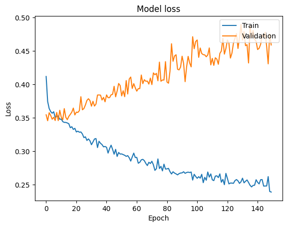

```python
#plot loss function
plt.plot(history_2.history['loss'])
plt.plot(history_2.history['val_loss'])
plt.title('Model loss')
plt.ylabel('Loss')
plt.xlabel('Epoch')
plt.legend(['Train', 'Validation'], loc='upper right')
```

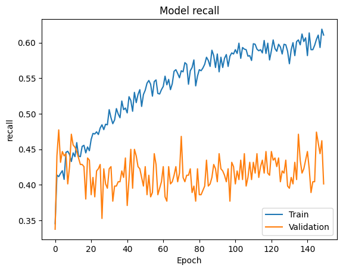

```python
#plot recall
plt.plot(history_2.history['recall'])
plt.plot(history_2.history['val_recall'])
plt.title('Model recall')
plt.ylabel('recall')
plt.xlabel('Epoch')
plt.legend(['Train', 'Validation'], loc='lower right')
```

```python
y_train_pred = model_2.predict(X_train)
y_train_pred = (y_train_pred > 0.5)
y_valid_pred = model_2.predict(X_valid)
y_valid_pred = (y_valid_pred > 0.5)
y_test_pred = model_2.predict(X_test)
y_test_pred = (y_test_pred > 0.5)
y_train_pred, y_valid_pred, y_test_pred #get predictions from model
```

```
200/200 ━━━━━━━━━━━━━━━━━━━━ 0s 1ms/step
50/50 ━━━━━━━━━━━━━━━━━━━━ 0s 1ms/step
63/63 ━━━━━━━━━━━━━━━━━━━━ 0s 2ms/step
```

```
(array([[ True],
        [False],
        [False],
        ...,
        [False],
        [ True],
        [False]]),
 array([[False],
        [False],
        [False],
        ...,
        [False],
        [False],
        [False]]),
 array([[False],
        [False],
        [False],
        ...,
        [ True],
        [False],
        [False]]))
```

```python
cr=classification_report(y_train, y_train_pred)
print(cr) #get stats from validation data
```

```
              precision    recall  f1-score   support

           0       0.91      0.99      0.95      5085
           1       0.96      0.63      0.76      1315

    accuracy                           0.92      6400
   macro avg       0.93      0.81      0.86      6400
weighted avg       0.92      0.92      0.91      6400
```

```python
cr=classification_report(y_valid, y_valid_pred)
print(cr) #get stats from validation data
```

```
              precision    recall  f1-score   support

           0       0.86      0.95      0.90      1271
           1       0.68      0.40      0.50       329

    accuracy                           0.84      1600
   macro avg       0.77      0.68      0.70      1600
weighted avg       0.82      0.84      0.82      1600
```

```python
recall_results['model_2'] = [f"Train: {recall_score(y_train, y_train_pred)}", f"Validation: {recall_score(y_valid, y_valid_pred)}"]
recall_results
```

```
{'model_0': ['Train: 0.5452471482889734', 'Validation: 0.48936170212765956'],
 'model_1': ['Train: 0.9140684410646388', 'Validation: 0.5714285714285714'],
 'model_2': ['Train: 0.6304182509505704', 'Validation: 0.4012158054711246']}
```

### Neural Network with Balanced Data (by applying SMOTE) and SGD Optimizer

```python
sm = SMOTE(random_state=42)
X_train_smote, y_train_smote = sm.fit_resample(X_train, y_train)
print(X_train_smote.shape, y_train_smote.shape)
```

```
(10170, 11) (10170,)
```

```python
backend.clear_session()
np.random.seed(42)
random.seed(42)
tf.random.set_seed(42)
```

```python
input_shape = X_train_smote.shape[1]
input_shape
```

```
11
```

```python
model_3 = Sequential()
# First hidden layer with 128 neurons and relu activation function, the input shape tuple denotes number of independent variables
model_3.add(Dense(128, activation='relu', input_shape=(11,)))

# Second hidden layer with 64 neurons and relu activation function
model_3.add(Dense(64, activation='relu'))

# Output layer with only one neuron and sigmoid as activation function will give the probability of students getting admitted into UCLA
model_3.add(Dense(1, activation='sigmoid'))

optimizer = SGD(learning_rate=0.01)
model_3.compile(loss='binary_crossentropy', optimizer=optimizer, metrics=['recall'])
```

```python
model_3.summary()
```

```
Model: "sequential"
```

```
┏━━━━━━━━━━━━━━━━━━━━━━━━━━━━━━━━━━━━━━┳━━━━━━━━━━━━━━━━━━━━━━━━━━━━━┳━━━━━━━━━━━━━━━━━┓
┃ Layer (type)                         ┃ Output Shape                ┃         Param # ┃
┡━━━━━━━━━━━━━━━━━━━━━━━━━━━━━━━━━━━━━━╇━━━━━━━━━━━━━━━━━━━━━━━━━━━━━╇━━━━━━━━━━━━━━━━━┩
│ dense (Dense)                        │ (None, 128)                 │           1,536 │
├──────────────────────────────────────┼─────────────────────────────┼─────────────────┤
│ dense_1 (Dense)                      │ (None, 64)                  │           8,256 │
├──────────────────────────────────────┼─────────────────────────────┼─────────────────┤
│ dense_2 (Dense)                      │ (None, 1)                   │              65 │
└──────────────────────────────────────┴─────────────────────────────┴─────────────────┘
```

```
 Total params: 9,857 (38.50 KB)
```

```
 Trainable params: 9,857 (38.50 KB)
```

```
 Non-trainable params: 0 (0.00 B)
```

```python
history_3 = model_3.fit(X_train_smote,
                    y_train_smote,
                    validation_data=(X_valid, y_valid),
                    batch_size=32,
                    epochs=150,
                    verbose=1)
```

```
318/318 ━━━━━━━━━━━━━━━━━━━━ 2s 2ms/step - loss: 0.6850 - recall: 0.6762 - val_loss: 0.6441 - val_recall: 0.7173
318/318 ━━━━━━━━━━━━━━━━━━━━ 1s 2ms/step - loss: 0.6179 - recall: 0.6865 - val_loss: 0.5958 - val_recall: 0.7143
318/318 ━━━━━━━━━━━━━━━━━━━━ 1s 2ms/step - loss: 0.5769 - recall: 0.6998 - val_loss: 0.5668 - val_recall: 0.7112
318/318 ━━━━━━━━━━━━━━━━━━━━ 1s 2ms/step - loss: 0.5523 - recall: 0.7088 - val_loss: 0.5480 - val_recall: 0.7295
318/318 ━━━━━━━━━━━━━━━━━━━━ 1s 2ms/step - loss: 0.5344 - recall: 0.7217 - val_loss: 0.5318 - val_recall: 0.7325
318/318 ━━━━━━━━━━━━━━━━━━━━ 1s 2ms/step - loss: 0.5186 - recall: 0.7377 - val_loss: 0.5163 - val_recall: 0.7416
318/318 ━━━━━━━━━━━━━━━━━━━━ 2s 3ms/step - loss: 0.5039 - recall: 0.7456 - val_loss: 0.5026 - val_recall: 0.7386
318/318 ━━━━━━━━━━━━━━━━━━━━ 1s 3ms/step - loss: 0.4907 - recall: 0.7542 - val_loss: 0.4907 - val_recall: 0.7416
318/318 ━━━━━━━━━━━━━━━━━━━━ 1s 3ms/step - loss: 0.4798 - recall: 0.7591 - val_loss: 0.4815 - val_recall: 0.7568
318/318 ━━━━━━━━━━━━━━━━━━━━ 1s 2ms/step - loss: 0.4713 - recall: 0.7614 - val_loss: 0.4746 - val_recall: 0.7599
318/318 ━━━━━━━━━━━━━━━━━━━━ 1s 2ms/step - loss: 0.4649 - recall: 0.7667 - val_loss: 0.4693 - val_recall: 0.7568
318/318 ━━━━━━━━━━━━━━━━━━━━ 1s 2ms/step - loss: 0.4599 - recall: 0.7731 - val_loss: 0.4654 - val_recall: 0.7599
318/318 ━━━━━━━━━━━━━━━━━━━━ 1s 2ms/step - loss: 0.4558 - recall: 0.7769 - val_loss: 0.4626 - val_recall: 0.7568
318/318 ━━━━━━━━━━━━━━━━━━━━ 1s 2ms/step - loss: 0.4524 - recall: 0.7798 - val_loss: 0.4603 - val_recall: 0.7538
318/318 ━━━━━━━━━━━━━━━━━━━━ 1s 2ms/step - loss: 0.4495 - recall: 0.7784 - val_loss: 0.4587 - val_recall: 0.7508
318/318 ━━━━━━━━━━━━━━━━━━━━ 1s 2ms/step - loss: 0.4469 - recall: 0.7801 - val_loss: 0.4572 - val_recall: 0.7538
318/318 ━━━━━━━━━━━━━━━━━━━━ 1s 2ms/step - loss: 0.4444 - recall: 0.7818 - val_loss: 0.4560 - val_recall: 0.7538
318/318 ━━━━━━━━━━━━━━━━━━━━ 1s 2ms/step - loss: 0.4423 - recall: 0.7816 - val_loss: 0.4549 - val_recall: 0.7568
318/318 ━━━━━━━━━━━━━━━━━━━━ 1s 2ms/step - loss: 0.4402 - recall: 0.7821 - val_loss: 0.4538 - val_recall: 0.7568
318/318 ━━━━━━━━━━━━━━━━━━━━ 1s 2ms/step - loss: 0.4383 - recall: 0.7842 - val_loss: 0.4531 - val_recall: 0.7629
318/318 ━━━━━━━━━━━━━━━━━━━━ 1s 2ms/step - loss: 0.4364 - recall: 0.7862 - val_loss: 0.4522 - val_recall: 0.7690
318/318 ━━━━━━━━━━━━━━━━━━━━ 1s 2ms/step - loss: 0.4346 - recall: 0.7872 - val_loss: 0.4512 - val_recall: 0.7720
318/318 ━━━━━━━━━━━━━━━━━━━━ 1s 2ms/step - loss: 0.4327 - recall: 0.7881 - val_loss: 0.4505 - val_recall: 0.7690
318/318 ━━━━━━━━━━━━━━━━━━━━ 1s 3ms/step - loss: 0.4309 - recall: 0.7897 - val_loss: 0.4501 - val_recall: 0.7720
318/318 ━━━━━━━━━━━━━━━━━━━━ 1s 3ms/step - loss: 0.4292 - recall: 0.7909 - val_loss: 0.4494 - val_recall: 0.7660
318/318 ━━━━━━━━━━━━━━━━━━━━ 1s 3ms/step - loss: 0.4275 - recall: 0.7920 - val_loss: 0.4489 - val_recall: 0.7629
318/318 ━━━━━━━━━━━━━━━━━━━━ 1s 3ms/step - loss: 0.4258 - recall: 0.7921 - val_loss: 0.4484 - val_recall: 0.7629
318/318 ━━━━━━━━━━━━━━━━━━━━ 1s 2ms/step - loss: 0.4241 - recall: 0.7930 - val_loss: 0.4479 - val_recall: 0.7660
318/318 ━━━━━━━━━━━━━━━━━━━━ 1s 2ms/step - loss: 0.4225 - recall: 0.7936 - val_loss: 0.4475 - val_recall: 0.7629
318/318 ━━━━━━━━━━━━━━━━━━━━ 1s 2ms/step - loss: 0.4209 - recall: 0.7942 - val_loss: 0.4468 - val_recall: 0.7629
318/318 ━━━━━━━━━━━━━━━━━━━━ 1s 2ms/step - loss: 0.4192 - recall: 0.7954 - val_loss: 0.4461 - val_recall: 0.7629
318/318 ━━━━━━━━━━━━━━━━━━━━ 1s 2ms/step - loss: 0.4176 - recall: 0.7962 - val_loss: 0.4458 - val_recall: 0.7629
318/318 ━━━━━━━━━━━━━━━━━━━━ 1s 2ms/step - loss: 0.4160 - recall: 0.7972 - val_loss: 0.4455 - val_recall: 0.7660
318/318 ━━━━━━━━━━━━━━━━━━━━ 1s 2ms/step - loss: 0.4144 - recall: 0.7987 - val_loss: 0.4451 - val_recall: 0.7690
318/318 ━━━━━━━━━━━━━━━━━━━━ 1s 2ms/step - loss: 0.4127 - recall: 0.8003 - val_loss: 0.4445 - val_recall: 0.7690
318/318 ━━━━━━━━━━━━━━━━━━━━ 1s 2ms/step - loss: 0.4111 - recall: 0.8012 - val_loss: 0.4439 - val_recall: 0.7751
318/318 ━━━━━━━━━━━━━━━━━━━━ 1s 2ms/step - loss: 0.4095 - recall: 0.8020 - val_loss: 0.4435 - val_recall: 0.7751
318/318 ━━━━━━━━━━━━━━━━━━━━ 1s 2ms/step - loss: 0.4079 - recall: 0.8031 - val_loss: 0.4428 - val_recall: 0.7751
318/318 ━━━━━━━━━━━━━━━━━━━━ 1s 2ms/step - loss: 0.4064 - recall: 0.8041 - val_loss: 0.4423 - val_recall: 0.7751
318/318 ━━━━━━━━━━━━━━━━━━━━ 1s 2ms/step - loss: 0.4048 - recall: 0.8050 - val_loss: 0.4418 - val_recall: 0.7751
```

[output cut: 95 more lines]

```
318/318 ━━━━━━━━━━━━━━━━━━━━ 1s 2ms/step - loss: 0.2675 - recall: 0.8975 - val_loss: 0.4644 - val_recall: 0.6596
318/318 ━━━━━━━━━━━━━━━━━━━━ 1s 2ms/step - loss: 0.2664 - recall: 0.8984 - val_loss: 0.4650 - val_recall: 0.6565
318/318 ━━━━━━━━━━━━━━━━━━━━ 1s 2ms/step - loss: 0.2652 - recall: 0.9005 - val_loss: 0.4658 - val_recall: 0.6565
318/318 ━━━━━━━━━━━━━━━━━━━━ 1s 2ms/step - loss: 0.2641 - recall: 0.8999 - val_loss: 0.4667 - val_recall: 0.6596
318/318 ━━━━━━━━━━━━━━━━━━━━ 1s 2ms/step - loss: 0.2629 - recall: 0.9019 - val_loss: 0.4669 - val_recall: 0.6596
318/318 ━━━━━━━━━━━━━━━━━━━━ 1s 2ms/step - loss: 0.2618 - recall: 0.9021 - val_loss: 0.4671 - val_recall: 0.6565
318/318 ━━━━━━━━━━━━━━━━━━━━ 1s 2ms/step - loss: 0.2606 - recall: 0.9027 - val_loss: 0.4685 - val_recall: 0.6565
318/318 ━━━━━━━━━━━━━━━━━━━━ 1s 3ms/step - loss: 0.2594 - recall: 0.9035 - val_loss: 0.4679 - val_recall: 0.6596
318/318 ━━━━━━━━━━━━━━━━━━━━ 1s 3ms/step - loss: 0.2583 - recall: 0.9047 - val_loss: 0.4683 - val_recall: 0.6596
318/318 ━━━━━━━━━━━━━━━━━━━━ 1s 3ms/step - loss: 0.2572 - recall: 0.9064 - val_loss: 0.4690 - val_recall: 0.6626
318/318 ━━━━━━━━━━━━━━━━━━━━ 1s 2ms/step - loss: 0.2560 - recall: 0.9065 - val_loss: 0.4695 - val_recall: 0.6565
318/318 ━━━━━━━━━━━━━━━━━━━━ 1s 2ms/step - loss: 0.2549 - recall: 0.9075 - val_loss: 0.4711 - val_recall: 0.6565
318/318 ━━━━━━━━━━━━━━━━━━━━ 1s 2ms/step - loss: 0.2537 - recall: 0.9088 - val_loss: 0.4712 - val_recall: 0.6535
318/318 ━━━━━━━━━━━━━━━━━━━━ 1s 2ms/step - loss: 0.2525 - recall: 0.9110 - val_loss: 0.4727 - val_recall: 0.6535
318/318 ━━━━━━━━━━━━━━━━━━━━ 1s 2ms/step - loss: 0.2513 - recall: 0.9104 - val_loss: 0.4730 - val_recall: 0.6565
```

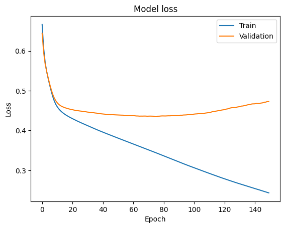

```python
#plot loss function
plt.plot(history_3.history['loss'])
plt.plot(history_3.history['val_loss'])
plt.title('Model loss')
plt.ylabel('Loss')
plt.xlabel('Epoch')
plt.legend(['Train', 'Validation'], loc='upper right')
```

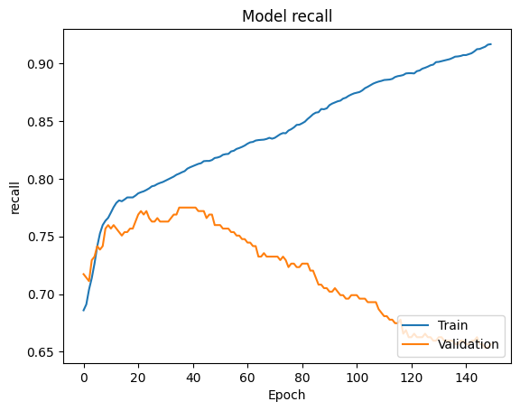

```python
#plot recall
plt.plot(history_3.history['recall'])
plt.plot(history_3.history['val_recall'])
plt.title('Model recall')
plt.ylabel('recall')
plt.xlabel('Epoch')
plt.legend(['Train', 'Validation'], loc='lower right')
```

```python
y_train_pred = model_3.predict(X_train_smote)
y_train_pred = (y_train_pred > 0.5)
y_valid_pred = model_3.predict(X_valid)
y_valid_pred = (y_valid_pred > 0.5)
y_test_pred = model_3.predict(X_test)
y_test_pred = (y_test_pred > 0.5)
y_train_pred, y_valid_pred, y_test_pred #get predictions from model
```

```
318/318 ━━━━━━━━━━━━━━━━━━━━ 1s 1ms/step
50/50 ━━━━━━━━━━━━━━━━━━━━ 0s 1ms/step
63/63 ━━━━━━━━━━━━━━━━━━━━ 0s 1ms/step
```

```
(array([[ True],
        [False],
        [False],
        ...,
        [ True],
        [ True],
        [ True]]),
 array([[ True],
        [False],
        [False],
        ...,
        [False],
        [False],
        [False]]),
 array([[False],
        [False],
        [False],
        ...,
        [ True],
        [False],
        [ True]]))
```

```python
cr=classification_report(y_train_smote, y_train_pred)
print(cr) #get stats from validation data
```

```
              precision    recall  f1-score   support

           0       0.91      0.90      0.90      5085
           1       0.90      0.91      0.90      5085

    accuracy                           0.90     10170
   macro avg       0.90      0.90      0.90     10170
weighted avg       0.90      0.90      0.90     10170
```

```python
cr=classification_report(y_valid, y_valid_pred)
print(cr) #get stats from validation data
```

```
              precision    recall  f1-score   support

           0       0.90      0.85      0.87      1271
           1       0.52      0.66      0.58       329

    accuracy                           0.81      1600
   macro avg       0.71      0.75      0.73      1600
weighted avg       0.83      0.81      0.81      1600
```

```python
print(y_train.shape, y_train_pred.shape)
print(y_valid.shape, y_valid_pred.shape)
```

```
(6400,) (10170, 1)
(1600,) (1600, 1)
```

```python
# Truncate y_train_pred if it has more samples than y_train
y_train_pred = y_train_pred[:len(y_train)]
y_valid_pred = y_valid_pred[:len(y_valid)]

# Reshape the predictions from (n, 1) to (n,)
y_train_pred = y_train_pred.reshape(-1)  # Convert to 1D array
y_valid_pred = y_valid_pred.reshape(-1)  # Convert to 1D array
```

```python
recall_results['model_3'] = [f"Train: {recall_score(y_train, y_train_pred)}", f"Validation: {recall_score(y_valid, y_valid_pred)}"]
recall_results
```

```
{'model_0': ['Train: 0.5452471482889734', 'Validation: 0.48936170212765956'],
 'model_1': ['Train: 0.9140684410646388', 'Validation: 0.5714285714285714'],
 'model_2': ['Train: 0.6304182509505704', 'Validation: 0.4012158054711246'],
 'model_3': ['Train: 0.8395437262357415', 'Validation: 0.6565349544072948']}
```

### Neural Network with Balanced Data (by applying SMOTE) and Adam Optimizer

```python
backend.clear_session()
np.random.seed(42)
random.seed(42)
tf.random.set_seed(42)
```

```python
model_4 = Sequential()
# First hidden layer with 128 neurons and relu activation function, the input shape tuple denotes number of independent variables
model_4.add(Dense(128, activation='relu', input_shape=(11,)))

# Second hidden layer with 64 neurons and relu activation function
model_4.add(Dense(64, activation='relu'))

# Output layer with only one neuron and sigmoid as activation function will give the probability of students getting admitted into UCLA
model_4.add(Dense(1, activation='sigmoid'))

optimizer = Adam(learning_rate=0.01)
model_4.compile(loss='binary_crossentropy', optimizer=optimizer, metrics=['recall'])
```

```python
model_4.summary()
```

```
Model: "sequential"
```

```
┏━━━━━━━━━━━━━━━━━━━━━━━━━━━━━━━━━━━━━━┳━━━━━━━━━━━━━━━━━━━━━━━━━━━━━┳━━━━━━━━━━━━━━━━━┓
┃ Layer (type)                         ┃ Output Shape                ┃         Param # ┃
┡━━━━━━━━━━━━━━━━━━━━━━━━━━━━━━━━━━━━━━╇━━━━━━━━━━━━━━━━━━━━━━━━━━━━━╇━━━━━━━━━━━━━━━━━┩
│ dense (Dense)                        │ (None, 128)                 │           1,536 │
├──────────────────────────────────────┼─────────────────────────────┼─────────────────┤
│ dense_1 (Dense)                      │ (None, 64)                  │           8,256 │
├──────────────────────────────────────┼─────────────────────────────┼─────────────────┤
│ dense_2 (Dense)                      │ (None, 1)                   │              65 │
└──────────────────────────────────────┴─────────────────────────────┴─────────────────┘
```

```
 Total params: 9,857 (38.50 KB)
```

```
 Trainable params: 9,857 (38.50 KB)
```

```
 Non-trainable params: 0 (0.00 B)
```

```python
history_4 = model_4.fit(X_train_smote,
                    y_train_smote,
                    validation_data=(X_valid, y_valid),
                    batch_size=32,
                    epochs=150,
                    verbose=1)
```

```
318/318 ━━━━━━━━━━━━━━━━━━━━ 2s 3ms/step - loss: 0.5341 - recall: 0.7149 - val_loss: 0.4485 - val_recall: 0.7599
318/318 ━━━━━━━━━━━━━━━━━━━━ 1s 2ms/step - loss: 0.4543 - recall: 0.7703 - val_loss: 0.4354 - val_recall: 0.7720
318/318 ━━━━━━━━━━━━━━━━━━━━ 1s 2ms/step - loss: 0.4342 - recall: 0.7888 - val_loss: 0.4600 - val_recall: 0.7964
318/318 ━━━━━━━━━━━━━━━━━━━━ 1s 2ms/step - loss: 0.4199 - recall: 0.8050 - val_loss: 0.4732 - val_recall: 0.7812
318/318 ━━━━━━━━━━━━━━━━━━━━ 1s 2ms/step - loss: 0.4104 - recall: 0.8171 - val_loss: 0.4692 - val_recall: 0.7599
318/318 ━━━━━━━━━━━━━━━━━━━━ 1s 2ms/step - loss: 0.3953 - recall: 0.8280 - val_loss: 0.5051 - val_recall: 0.7660
318/318 ━━━━━━━━━━━━━━━━━━━━ 2s 3ms/step - loss: 0.3820 - recall: 0.8497 - val_loss: 0.4978 - val_recall: 0.7538
318/318 ━━━━━━━━━━━━━━━━━━━━ 1s 3ms/step - loss: 0.3660 - recall: 0.8590 - val_loss: 0.5129 - val_recall: 0.7720
318/318 ━━━━━━━━━━━━━━━━━━━━ 1s 3ms/step - loss: 0.3566 - recall: 0.8690 - val_loss: 0.5310 - val_recall: 0.7660
318/318 ━━━━━━━━━━━━━━━━━━━━ 1s 3ms/step - loss: 0.3422 - recall: 0.8791 - val_loss: 0.5339 - val_recall: 0.7538
318/318 ━━━━━━━━━━━━━━━━━━━━ 1s 2ms/step - loss: 0.3298 - recall: 0.8903 - val_loss: 0.5381 - val_recall: 0.7264
318/318 ━━━━━━━━━━━━━━━━━━━━ 1s 2ms/step - loss: 0.3202 - recall: 0.8906 - val_loss: 0.5630 - val_recall: 0.7477
318/318 ━━━━━━━━━━━━━━━━━━━━ 1s 2ms/step - loss: 0.3122 - recall: 0.9028 - val_loss: 0.5834 - val_recall: 0.7204
318/318 ━━━━━━━━━━━━━━━━━━━━ 1s 2ms/step - loss: 0.2984 - recall: 0.9085 - val_loss: 0.5617 - val_recall: 0.7204
318/318 ━━━━━━━━━━━━━━━━━━━━ 1s 2ms/step - loss: 0.2884 - recall: 0.9203 - val_loss: 0.5729 - val_recall: 0.7173
318/318 ━━━━━━━━━━━━━━━━━━━━ 1s 2ms/step - loss: 0.2864 - recall: 0.9129 - val_loss: 0.5911 - val_recall: 0.7173
318/318 ━━━━━━━━━━━━━━━━━━━━ 1s 2ms/step - loss: 0.2771 - recall: 0.9125 - val_loss: 0.6280 - val_recall: 0.7173
318/318 ━━━━━━━━━━━━━━━━━━━━ 1s 2ms/step - loss: 0.2737 - recall: 0.9124 - val_loss: 0.6162 - val_recall: 0.7082
318/318 ━━━━━━━━━━━━━━━━━━━━ 2s 3ms/step - loss: 0.2614 - recall: 0.9220 - val_loss: 0.6682 - val_recall: 0.6930
318/318 ━━━━━━━━━━━━━━━━━━━━ 1s 4ms/step - loss: 0.2589 - recall: 0.9237 - val_loss: 0.6802 - val_recall: 0.7264
318/318 ━━━━━━━━━━━━━━━━━━━━ 1s 4ms/step - loss: 0.2554 - recall: 0.9207 - val_loss: 0.6932 - val_recall: 0.7143
318/318 ━━━━━━━━━━━━━━━━━━━━ 1s 3ms/step - loss: 0.2508 - recall: 0.9273 - val_loss: 0.6649 - val_recall: 0.7021
318/318 ━━━━━━━━━━━━━━━━━━━━ 1s 2ms/step - loss: 0.2419 - recall: 0.9267 - val_loss: 0.6876 - val_recall: 0.7173
318/318 ━━━━━━━━━━━━━━━━━━━━ 1s 2ms/step - loss: 0.2368 - recall: 0.9307 - val_loss: 0.7222 - val_recall: 0.6809
318/318 ━━━━━━━━━━━━━━━━━━━━ 1s 2ms/step - loss: 0.2403 - recall: 0.9353 - val_loss: 0.7158 - val_recall: 0.6900
318/318 ━━━━━━━━━━━━━━━━━━━━ 1s 2ms/step - loss: 0.2346 - recall: 0.9348 - val_loss: 0.7377 - val_recall: 0.6991
318/318 ━━━━━━━━━━━━━━━━━━━━ 1s 2ms/step - loss: 0.2340 - recall: 0.9351 - val_loss: 0.7420 - val_recall: 0.7021
318/318 ━━━━━━━━━━━━━━━━━━━━ 1s 2ms/step - loss: 0.2237 - recall: 0.9378 - val_loss: 0.7839 - val_recall: 0.6869
318/318 ━━━━━━━━━━━━━━━━━━━━ 1s 2ms/step - loss: 0.2172 - recall: 0.9432 - val_loss: 0.7674 - val_recall: 0.6596
318/318 ━━━━━━━━━━━━━━━━━━━━ 1s 2ms/step - loss: 0.2081 - recall: 0.9392 - val_loss: 0.7850 - val_recall: 0.6657
318/318 ━━━━━━━━━━━━━━━━━━━━ 1s 2ms/step - loss: 0.2138 - recall: 0.9406 - val_loss: 0.8424 - val_recall: 0.6778
318/318 ━━━━━━━━━━━━━━━━━━━━ 1s 2ms/step - loss: 0.2089 - recall: 0.9444 - val_loss: 0.8083 - val_recall: 0.6687
318/318 ━━━━━━━━━━━━━━━━━━━━ 1s 4ms/step - loss: 0.2083 - recall: 0.9436 - val_loss: 0.8275 - val_recall: 0.6596
318/318 ━━━━━━━━━━━━━━━━━━━━ 1s 4ms/step - loss: 0.2100 - recall: 0.9416 - val_loss: 0.9095 - val_recall: 0.6778
318/318 ━━━━━━━━━━━━━━━━━━━━ 1s 4ms/step - loss: 0.1998 - recall: 0.9491 - val_loss: 0.8766 - val_recall: 0.6596
318/318 ━━━━━━━━━━━━━━━━━━━━ 1s 4ms/step - loss: 0.2060 - recall: 0.9425 - val_loss: 0.8674 - val_recall: 0.6809
318/318 ━━━━━━━━━━━━━━━━━━━━ 2s 4ms/step - loss: 0.1986 - recall: 0.9426 - val_loss: 0.8821 - val_recall: 0.6778
318/318 ━━━━━━━━━━━━━━━━━━━━ 1s 3ms/step - loss: 0.1895 - recall: 0.9443 - val_loss: 0.9027 - val_recall: 0.6596
318/318 ━━━━━━━━━━━━━━━━━━━━ 1s 2ms/step - loss: 0.1942 - recall: 0.9466 - val_loss: 0.9591 - val_recall: 0.6687
318/318 ━━━━━━━━━━━━━━━━━━━━ 1s 2ms/step - loss: 0.1877 - recall: 0.9473 - val_loss: 0.9407 - val_recall: 0.6626
```

[output cut: 95 more lines]

```
318/318 ━━━━━━━━━━━━━━━━━━━━ 1s 2ms/step - loss: 0.0977 - recall: 0.9792 - val_loss: 1.8152 - val_recall: 0.5745
318/318 ━━━━━━━━━━━━━━━━━━━━ 1s 2ms/step - loss: 0.0943 - recall: 0.9819 - val_loss: 1.8410 - val_recall: 0.5836
318/318 ━━━━━━━━━━━━━━━━━━━━ 1s 2ms/step - loss: 0.0925 - recall: 0.9819 - val_loss: 1.7923 - val_recall: 0.5684
318/318 ━━━━━━━━━━━━━━━━━━━━ 1s 2ms/step - loss: 0.1369 - recall: 0.9745 - val_loss: 1.6985 - val_recall: 0.5836
318/318 ━━━━━━━━━━━━━━━━━━━━ 1s 2ms/step - loss: 0.1000 - recall: 0.9782 - val_loss: 1.7951 - val_recall: 0.6170
318/318 ━━━━━━━━━━━━━━━━━━━━ 1s 2ms/step - loss: 0.1108 - recall: 0.9782 - val_loss: 1.8812 - val_recall: 0.6049
318/318 ━━━━━━━━━━━━━━━━━━━━ 2s 3ms/step - loss: 0.0852 - recall: 0.9857 - val_loss: 1.8831 - val_recall: 0.5957
318/318 ━━━━━━━━━━━━━━━━━━━━ 1s 4ms/step - loss: 0.1074 - recall: 0.9774 - val_loss: 1.7736 - val_recall: 0.5988
318/318 ━━━━━━━━━━━━━━━━━━━━ 1s 3ms/step - loss: 0.0982 - recall: 0.9801 - val_loss: 1.8257 - val_recall: 0.6231
318/318 ━━━━━━━━━━━━━━━━━━━━ 1s 4ms/step - loss: 0.0780 - recall: 0.9871 - val_loss: 2.0465 - val_recall: 0.5957
318/318 ━━━━━━━━━━━━━━━━━━━━ 1s 2ms/step - loss: 0.0871 - recall: 0.9852 - val_loss: 1.7806 - val_recall: 0.5957
318/318 ━━━━━━━━━━━━━━━━━━━━ 1s 2ms/step - loss: 0.1313 - recall: 0.9684 - val_loss: 1.8415 - val_recall: 0.5775
318/318 ━━━━━━━━━━━━━━━━━━━━ 1s 2ms/step - loss: 0.1131 - recall: 0.9780 - val_loss: 1.8393 - val_recall: 0.5927
318/318 ━━━━━━━━━━━━━━━━━━━━ 1s 2ms/step - loss: 0.0956 - recall: 0.9795 - val_loss: 1.8497 - val_recall: 0.6018
318/318 ━━━━━━━━━━━━━━━━━━━━ 1s 2ms/step - loss: 0.0977 - recall: 0.9814 - val_loss: 1.9621 - val_recall: 0.6018
```

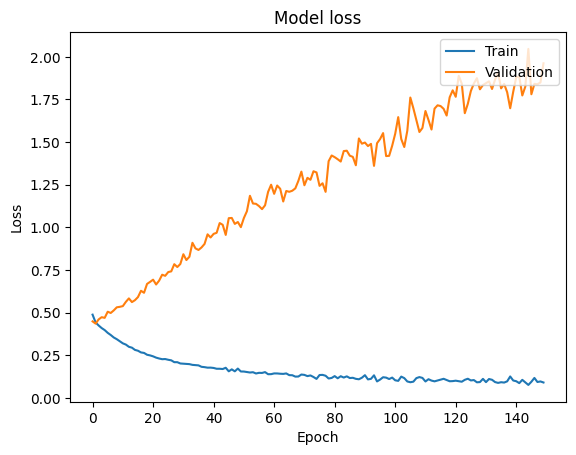

```python
#plot loss function
plt.plot(history_4.history['loss'])
plt.plot(history_4.history['val_loss'])
plt.title('Model loss')
plt.ylabel('Loss')
plt.xlabel('Epoch')
plt.legend(['Train', 'Validation'], loc='upper right')
```

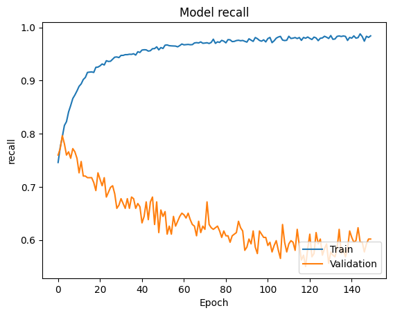

```python
#plot recall
plt.plot(history_4.history['recall'])
plt.plot(history_4.history['val_recall'])
plt.title('Model recall')
plt.ylabel('recall')
plt.xlabel('Epoch')
plt.legend(['Train', 'Validation'], loc='lower right')
```

```python
y_train_pred = model_4.predict(X_train_smote)
y_train_pred = (y_train_pred > 0.5)
y_valid_pred = model_4.predict(X_valid)
y_valid_pred = (y_valid_pred > 0.5)
y_test_pred = model_4.predict(X_test)
y_test_pred = (y_test_pred > 0.5)
y_train_pred, y_valid_pred, y_test_pred #get predictions from model
```

```
318/318 ━━━━━━━━━━━━━━━━━━━━ 1s 2ms/step
50/50 ━━━━━━━━━━━━━━━━━━━━ 0s 1ms/step
63/63 ━━━━━━━━━━━━━━━━━━━━ 0s 1ms/step
```

```
(array([[ True],
        [False],
        [False],
        ...,
        [ True],
        [ True],
        [ True]]),
 array([[ True],
        [False],
        [False],
        ...,
        [False],
        [False],
        [False]]),
 array([[False],
        [False],
        [False],
        ...,
        [ True],
        [False],
        [ True]]))
```

```python
cr=classification_report(y_train_smote, y_train_pred)
print(cr) #get stats from validation data
```

```
              precision    recall  f1-score   support

           0       0.97      0.95      0.96      5085
           1       0.95      0.97      0.96      5085

    accuracy                           0.96     10170
   macro avg       0.96      0.96      0.96     10170
weighted avg       0.96      0.96      0.96     10170
```

```python
cr=classification_report(y_valid, y_valid_pred)
print(cr) #get stats from validation data
```

```
              precision    recall  f1-score   support

           0       0.89      0.85      0.87      1271
           1       0.51      0.60      0.55       329

    accuracy                           0.80      1600
   macro avg       0.70      0.72      0.71      1600
weighted avg       0.81      0.80      0.80      1600
```

```python
# Truncate y_train_pred if it has more samples than y_train
y_train_pred = y_train_pred[:len(y_train)]
y_valid_pred = y_valid_pred[:len(y_valid)]

# Flatten or reshape the predictions from (n, 1) to (n,)
y_train_pred = y_train_pred.reshape(-1)  # Convert to 1D array
y_valid_pred = y_valid_pred.reshape(-1)  # Convert to 1D array
```

```python
recall_results['model_4'] = [f"Train: {recall_score(y_train, y_train_pred)}", f"Validation: {recall_score(y_valid, y_valid_pred)}"]
recall_results
```

```
{'model_0': ['Train: 0.5452471482889734', 'Validation: 0.48936170212765956'],
 'model_1': ['Train: 0.9140684410646388', 'Validation: 0.5714285714285714'],
 'model_2': ['Train: 0.6304182509505704', 'Validation: 0.4012158054711246'],
 'model_3': ['Train: 0.8395437262357415', 'Validation: 0.6565349544072948'],
 'model_4': ['Train: 0.9543726235741445', 'Validation: 0.601823708206687']}
```

### Neural Network with Balanced Data (by applying SMOTE), Adam Optimizer, and Dropout

```python
backend.clear_session()
np.random.seed(42)
random.seed(42)
tf.random.set_seed(42)
```

```python
model_5 = Sequential()
# First hidden layer with 128 neurons and relu activation function, the input shape tuple denotes number of independent variables
model_5.add(Dense(128, activation='relu', input_shape=(11,)))

#switching 20% of neurons off randomly at each iteration to avoid overfitting
model_5.add(Dropout(0.2))

# Second hidden layer with 64 neurons and relu activation function
model_5.add(Dense(64, activation='relu'))

#switching 10% of neurons off randomly at each iteration to avoid overfitting
model_5.add(Dropout(0.1))

# Output layer with only one neuron and sigmoid as activation function will give the probability of students getting admitted into UCLA
model_5.add(Dense(1, activation='sigmoid'))

optimizer = Adam(learning_rate=0.01)
model_5.compile(loss='binary_crossentropy', optimizer=optimizer, metrics=['recall'])
```

```python
model_5.summary()
```

```
Model: "sequential"
```

```
┏━━━━━━━━━━━━━━━━━━━━━━━━━━━━━━━━━━━━━━┳━━━━━━━━━━━━━━━━━━━━━━━━━━━━━┳━━━━━━━━━━━━━━━━━┓
┃ Layer (type)                         ┃ Output Shape                ┃         Param # ┃
┡━━━━━━━━━━━━━━━━━━━━━━━━━━━━━━━━━━━━━━╇━━━━━━━━━━━━━━━━━━━━━━━━━━━━━╇━━━━━━━━━━━━━━━━━┩
│ dense (Dense)                        │ (None, 128)                 │           1,536 │
├──────────────────────────────────────┼─────────────────────────────┼─────────────────┤
│ dropout (Dropout)                    │ (None, 128)                 │               0 │
├──────────────────────────────────────┼─────────────────────────────┼─────────────────┤
│ dense_1 (Dense)                      │ (None, 64)                  │           8,256 │
├──────────────────────────────────────┼─────────────────────────────┼─────────────────┤
│ dropout_1 (Dropout)                  │ (None, 64)                  │               0 │
├──────────────────────────────────────┼─────────────────────────────┼─────────────────┤
│ dense_2 (Dense)                      │ (None, 1)                   │              65 │
└──────────────────────────────────────┴─────────────────────────────┴─────────────────┘
```

```
 Total params: 9,857 (38.50 KB)
```

```
 Trainable params: 9,857 (38.50 KB)
```

```
 Non-trainable params: 0 (0.00 B)
```

```python
history_5 = model_5.fit(X_train_smote,
                    y_train_smote,
                    validation_data=(X_valid, y_valid),
                    batch_size=32,
                    epochs=150,
                    verbose=1)
```

```
318/318 ━━━━━━━━━━━━━━━━━━━━ 4s 4ms/step - loss: 0.5424 - recall: 0.7120 - val_loss: 0.4674 - val_recall: 0.7751
318/318 ━━━━━━━━━━━━━━━━━━━━ 2s 2ms/step - loss: 0.4749 - recall: 0.7645 - val_loss: 0.4784 - val_recall: 0.8024
318/318 ━━━━━━━━━━━━━━━━━━━━ 1s 2ms/step - loss: 0.4640 - recall: 0.7680 - val_loss: 0.4442 - val_recall: 0.7447
318/318 ━━━━━━━━━━━━━━━━━━━━ 2s 3ms/step - loss: 0.4517 - recall: 0.7655 - val_loss: 0.4610 - val_recall: 0.7568
318/318 ━━━━━━━━━━━━━━━━━━━━ 1s 3ms/step - loss: 0.4442 - recall: 0.7697 - val_loss: 0.4716 - val_recall: 0.7386
318/318 ━━━━━━━━━━━━━━━━━━━━ 1s 4ms/step - loss: 0.4385 - recall: 0.7502 - val_loss: 0.4591 - val_recall: 0.7477
318/318 ━━━━━━━━━━━━━━━━━━━━ 1s 3ms/step - loss: 0.4307 - recall: 0.7810 - val_loss: 0.4412 - val_recall: 0.7234
318/318 ━━━━━━━━━━━━━━━━━━━━ 1s 2ms/step - loss: 0.4228 - recall: 0.7830 - val_loss: 0.4646 - val_recall: 0.7356
318/318 ━━━━━━━━━━━━━━━━━━━━ 1s 2ms/step - loss: 0.4202 - recall: 0.7890 - val_loss: 0.4788 - val_recall: 0.7416
318/318 ━━━━━━━━━━━━━━━━━━━━ 1s 2ms/step - loss: 0.4142 - recall: 0.7925 - val_loss: 0.4566 - val_recall: 0.7264
318/318 ━━━━━━━━━━━━━━━━━━━━ 1s 2ms/step - loss: 0.4096 - recall: 0.7847 - val_loss: 0.4665 - val_recall: 0.6900
318/318 ━━━━━━━━━━━━━━━━━━━━ 1s 2ms/step - loss: 0.4022 - recall: 0.7980 - val_loss: 0.4777 - val_recall: 0.7599
318/318 ━━━━━━━━━━━━━━━━━━━━ 1s 2ms/step - loss: 0.3942 - recall: 0.8394 - val_loss: 0.4727 - val_recall: 0.7416
318/318 ━━━━━━━━━━━━━━━━━━━━ 1s 2ms/step - loss: 0.3870 - recall: 0.8450 - val_loss: 0.4646 - val_recall: 0.7720
318/318 ━━━━━━━━━━━━━━━━━━━━ 1s 2ms/step - loss: 0.3852 - recall: 0.8528 - val_loss: 0.4680 - val_recall: 0.7812
318/318 ━━━━━━━━━━━━━━━━━━━━ 1s 2ms/step - loss: 0.3879 - recall: 0.8534 - val_loss: 0.4574 - val_recall: 0.7599
318/318 ━━━━━━━━━━━━━━━━━━━━ 2s 3ms/step - loss: 0.3843 - recall: 0.8587 - val_loss: 0.4733 - val_recall: 0.7508
318/318 ━━━━━━━━━━━━━━━━━━━━ 1s 4ms/step - loss: 0.3775 - recall: 0.8492 - val_loss: 0.4893 - val_recall: 0.7629
318/318 ━━━━━━━━━━━━━━━━━━━━ 1s 4ms/step - loss: 0.3758 - recall: 0.8609 - val_loss: 0.4843 - val_recall: 0.7508
318/318 ━━━━━━━━━━━━━━━━━━━━ 1s 4ms/step - loss: 0.3669 - recall: 0.8646 - val_loss: 0.4998 - val_recall: 0.7720
318/318 ━━━━━━━━━━━━━━━━━━━━ 1s 3ms/step - loss: 0.3640 - recall: 0.8694 - val_loss: 0.4714 - val_recall: 0.7842
318/318 ━━━━━━━━━━━━━━━━━━━━ 1s 2ms/step - loss: 0.3600 - recall: 0.8710 - val_loss: 0.4665 - val_recall: 0.7720
318/318 ━━━━━━━━━━━━━━━━━━━━ 1s 2ms/step - loss: 0.3630 - recall: 0.8672 - val_loss: 0.4755 - val_recall: 0.7690
318/318 ━━━━━━━━━━━━━━━━━━━━ 1s 2ms/step - loss: 0.3503 - recall: 0.8749 - val_loss: 0.4702 - val_recall: 0.7599
318/318 ━━━━━━━━━━━━━━━━━━━━ 1s 2ms/step - loss: 0.3494 - recall: 0.8737 - val_loss: 0.4885 - val_recall: 0.7660
318/318 ━━━━━━━━━━━━━━━━━━━━ 1s 2ms/step - loss: 0.3547 - recall: 0.8801 - val_loss: 0.4863 - val_recall: 0.7599
318/318 ━━━━━━━━━━━━━━━━━━━━ 1s 2ms/step - loss: 0.3523 - recall: 0.8764 - val_loss: 0.4851 - val_recall: 0.7599
318/318 ━━━━━━━━━━━━━━━━━━━━ 1s 2ms/step - loss: 0.3448 - recall: 0.8824 - val_loss: 0.4768 - val_recall: 0.7568
318/318 ━━━━━━━━━━━━━━━━━━━━ 1s 2ms/step - loss: 0.3424 - recall: 0.8864 - val_loss: 0.4755 - val_recall: 0.7477
318/318 ━━━━━━━━━━━━━━━━━━━━ 1s 3ms/step - loss: 0.3410 - recall: 0.8842 - val_loss: 0.4974 - val_recall: 0.7447
318/318 ━━━━━━━━━━━━━━━━━━━━ 1s 4ms/step - loss: 0.3408 - recall: 0.8808 - val_loss: 0.4948 - val_recall: 0.7477
318/318 ━━━━━━━━━━━━━━━━━━━━ 1s 4ms/step - loss: 0.3450 - recall: 0.8869 - val_loss: 0.4882 - val_recall: 0.7143
318/318 ━━━━━━━━━━━━━━━━━━━━ 2s 2ms/step - loss: 0.3483 - recall: 0.8804 - val_loss: 0.4962 - val_recall: 0.7538
318/318 ━━━━━━━━━━━━━━━━━━━━ 1s 2ms/step - loss: 0.3395 - recall: 0.8863 - val_loss: 0.5003 - val_recall: 0.7356
318/318 ━━━━━━━━━━━━━━━━━━━━ 1s 2ms/step - loss: 0.3398 - recall: 0.8863 - val_loss: 0.5042 - val_recall: 0.7568
318/318 ━━━━━━━━━━━━━━━━━━━━ 1s 2ms/step - loss: 0.3294 - recall: 0.8926 - val_loss: 0.5103 - val_recall: 0.7812
318/318 ━━━━━━━━━━━━━━━━━━━━ 1s 2ms/step - loss: 0.3315 - recall: 0.8918 - val_loss: 0.4869 - val_recall: 0.7538
318/318 ━━━━━━━━━━━━━━━━━━━━ 1s 2ms/step - loss: 0.3313 - recall: 0.8948 - val_loss: 0.5110 - val_recall: 0.7356
318/318 ━━━━━━━━━━━━━━━━━━━━ 1s 2ms/step - loss: 0.3357 - recall: 0.8857 - val_loss: 0.4730 - val_recall: 0.7477
318/318 ━━━━━━━━━━━━━━━━━━━━ 1s 2ms/step - loss: 0.3297 - recall: 0.8929 - val_loss: 0.4978 - val_recall: 0.7629
```

[output cut: 95 more lines]

```
318/318 ━━━━━━━━━━━━━━━━━━━━ 1s 2ms/step - loss: 0.2664 - recall: 0.9204 - val_loss: 0.6012 - val_recall: 0.7112
318/318 ━━━━━━━━━━━━━━━━━━━━ 1s 3ms/step - loss: 0.2630 - recall: 0.9241 - val_loss: 0.6013 - val_recall: 0.7021
318/318 ━━━━━━━━━━━━━━━━━━━━ 1s 2ms/step - loss: 0.2614 - recall: 0.9182 - val_loss: 0.5701 - val_recall: 0.6960
318/318 ━━━━━━━━━━━━━━━━━━━━ 1s 2ms/step - loss: 0.2575 - recall: 0.9177 - val_loss: 0.5965 - val_recall: 0.7082
318/318 ━━━━━━━━━━━━━━━━━━━━ 1s 2ms/step - loss: 0.2548 - recall: 0.9193 - val_loss: 0.5721 - val_recall: 0.7052
318/318 ━━━━━━━━━━━━━━━━━━━━ 1s 2ms/step - loss: 0.2539 - recall: 0.9239 - val_loss: 0.5563 - val_recall: 0.6839
318/318 ━━━━━━━━━━━━━━━━━━━━ 1s 2ms/step - loss: 0.2540 - recall: 0.9191 - val_loss: 0.5563 - val_recall: 0.7234
318/318 ━━━━━━━━━━━━━━━━━━━━ 1s 3ms/step - loss: 0.2665 - recall: 0.9198 - val_loss: 0.5686 - val_recall: 0.6869
318/318 ━━━━━━━━━━━━━━━━━━━━ 1s 3ms/step - loss: 0.2536 - recall: 0.9240 - val_loss: 0.5626 - val_recall: 0.7052
318/318 ━━━━━━━━━━━━━━━━━━━━ 1s 4ms/step - loss: 0.2618 - recall: 0.9153 - val_loss: 0.5165 - val_recall: 0.7021
318/318 ━━━━━━━━━━━━━━━━━━━━ 1s 4ms/step - loss: 0.2444 - recall: 0.9302 - val_loss: 0.5953 - val_recall: 0.6991
318/318 ━━━━━━━━━━━━━━━━━━━━ 1s 4ms/step - loss: 0.2570 - recall: 0.9257 - val_loss: 0.5852 - val_recall: 0.7143
318/318 ━━━━━━━━━━━━━━━━━━━━ 1s 3ms/step - loss: 0.2737 - recall: 0.9273 - val_loss: 0.5435 - val_recall: 0.7143
318/318 ━━━━━━━━━━━━━━━━━━━━ 1s 2ms/step - loss: 0.2557 - recall: 0.9291 - val_loss: 0.5741 - val_recall: 0.7112
318/318 ━━━━━━━━━━━━━━━━━━━━ 1s 2ms/step - loss: 0.2563 - recall: 0.9292 - val_loss: 0.5623 - val_recall: 0.6839
```

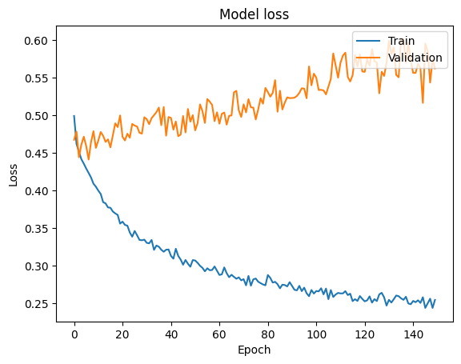

```python
#plot loss function
plt.plot(history_5.history['loss'])
plt.plot(history_5.history['val_loss'])
plt.title('Model loss')
plt.ylabel('Loss')
plt.xlabel('Epoch')
plt.legend(['Train', 'Validation'], loc='upper right')
```

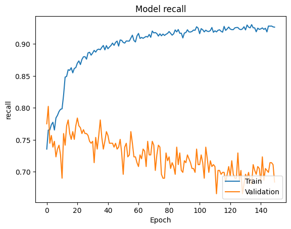

```python
#plot recall
plt.plot(history_5.history['recall'])
plt.plot(history_5.history['val_recall'])
plt.title('Model recall')
plt.ylabel('recall')
plt.xlabel('Epoch')
plt.legend(['Train', 'Validation'], loc='lower right')
```

```python
y_train_pred = model_5.predict(X_train_smote)
y_train_pred = (y_train_pred > 0.5)
y_valid_pred = model_5.predict(X_valid)
y_valid_pred = (y_valid_pred > 0.5)
y_test_pred = model_5.predict(X_test)
y_test_pred = (y_test_pred > 0.5)
y_train_pred, y_valid_pred, y_test_pred #get predictions from model
```

```
318/318 ━━━━━━━━━━━━━━━━━━━━ 1s 1ms/step
50/50 ━━━━━━━━━━━━━━━━━━━━ 0s 1ms/step
63/63 ━━━━━━━━━━━━━━━━━━━━ 0s 1ms/step
```

```
(array([[ True],
        [False],
        [False],
        ...,
        [ True],
        [ True],
        [ True]]),
 array([[ True],
        [False],
        [ True],
        ...,
        [False],
        [ True],
        [False]]),
 array([[False],
        [False],
        [False],
        ...,
        [ True],
        [False],
        [ True]]))
```

```python
cr=classification_report(y_train_smote, y_train_pred)
print(cr) #get stats from train data
```

```
              precision    recall  f1-score   support

           0       0.97      0.88      0.93      5085
           1       0.89      0.98      0.93      5085

    accuracy                           0.93     10170
   macro avg       0.93      0.93      0.93     10170
weighted avg       0.93      0.93      0.93     10170
```

```python
cr=classification_report(y_valid, y_valid_pred)
print(cr) #get stats from validation data
```

```
              precision    recall  f1-score   support

           0       0.91      0.81      0.86      1271
           1       0.49      0.68      0.57       329

    accuracy                           0.79      1600
   macro avg       0.70      0.75      0.71      1600
weighted avg       0.82      0.79      0.80      1600
```

```python
# Truncate y_train_pred if it has more samples than y_train
y_train_pred = y_train_pred[:len(y_train)]
y_valid_pred = y_valid_pred[:len(y_valid)]

# Flatten or reshape the predictions from (n, 1) to (n,)
y_train_pred = y_train_pred.reshape(-1)  # Convert to 1D array
y_valid_pred = y_valid_pred.reshape(-1)  # Convert to 1D array
```

```python
recall_results['model_5'] = [f"Train: {recall_score(y_train, y_train_pred)}", f"Validation: {recall_score(y_valid, y_valid_pred)}"]
```

## Model Performance Comparison and Final Model Selection

```python
recall_results
```

```
{'model_0': ['Train: 0.5452471482889734', 'Validation: 0.48936170212765956'],
 'model_1': ['Train: 0.9140684410646388', 'Validation: 0.5714285714285714'],
 'model_2': ['Train: 0.6304182509505704', 'Validation: 0.4012158054711246'],
 'model_3': ['Train: 0.8395437262357415', 'Validation: 0.6565349544072948'],
 'model_4': ['Train: 0.9543726235741445', 'Validation: 0.601823708206687'],
 'model_5': ['Train: 0.9574144486692016', 'Validation: 0.6838905775075987']}
```

The model with the best recall score across both the Training and Validation datasets was model 5:

**The Neural Network with SMOTE, Adam Optimizer, and Dropout.**

Therefore, we will choose this model.

## Actionable Insights and Business Recommendations

- The churn prediction neural network model we chose (SMOTE, Adam Optimizer, and Dropout) can be utilized by the bank to predict customer churn and improve retention efforts to keep customers.
- Some insights are that inactive customers have a much higher chance of churning.
- Customers with lower credits scores and bank account balances are also more likely to churn.
- Customers with less than 2 products at the bank have an increased likelihood of churning.

Based on these insights, the bank can create re-engagement strategies to engage inactive customers, offer credit-building/helpful savings products for customers with lower credit scores or bank account balances, and implement cross-selling/upselling strategies to increase the number of products customers use within the bank. By using the model we created and trained, the bank can streamline these retention strategies.